# Project: Flights Data Analysis

Author: Andrea Claudia Villanca Rosales

- Introduction
- Relevant Questions
- Data Wrangling
  - Gathering
  - General Properties
  - Assessing
  - Cleaning
  - Feature Engineering
- Storing
- Exploratory Data Analysis
  - Univariate Exploration
  - Bivariate Exploration
  - Multivariate Exploration
- Conclusions
- Appendix

## Introduction

This document explores the U.S. Department of Transportation (U.S.DOT) dataset of 2007 flights in the United States. This dataset provides information about airline on-time performance and flight delays. It is based on data filed by airlines each month with the Department of Transportation’s Bureau of Transportation Statistics (Office of Airline Information), as described in 14 CFR Part 234 of DOT's regulations. It covers non stop scheduled-service flights between points within the United States (including territories) by the nineteen (19) U.S. air carriers that have at least one percent of total domestic scheduled-service passenger revenues, and the two (2) carriers that reported flight delay data voluntarily during 2007.

The goal of this project is to conduct an exploratory data analysis on the flights dataset in order to figure out which features are more related to a flight delay.

A flight is counted as "on time" if it operated less than 15 minutes after the scheduled time shown in the carriers' Computerized Reservations Systems (CRS), [according to U.S.DOT](https://www.bts.dot.gov/explore-topics-and-geography/topics/airline-time-performance-and-causes-flight-delays). The delay analysis in this project will focus on arrival delays, specifically A+15 (arrival at the gate within 15 minutes after scheduled arrival), as that is the measure that the [U.S.DOT reports](https://www.transportation.gov/airconsumer/air-travel-consumer-reports-2008).

## Relevant Questions

**Univariate Analysis**

- What is the distribution of delayed flights in 2007?
- What is the distribution of flights per month?
- What is the distribution of flights per day of week?
- What is the distribution of flights on weekend and weekday? Do people travel more on any of them?
- What is the distribution of flights per hour (based on Scheduled Arrival Time)? What are the preferred times for flights to occur?
- What are the Top 5 Carriers based on their annual number of flights? What is the airline that had the most flights in 2007?
- What are the Top 10 Airports based on their annual amount of flights as origin?
- What are the Top 10 Airports based on their annual amount of flights as destination?
- What are the Top 5 Flight Numbers based on their annual number of operations? What are the Routes associated?
- What are the Top 10 Routes (origin - destination) based on their annual number of operations?
- What is the distribution of Distance between airports?
- What is the distribution of Scheduled Elapsed Time?

**Bivariate Analysis**

- What is the percentage of flight operations that arrived late each month?
- What is the percentage of flight operations that arrived late each day of week?
- What is the percentage of flight operations that arrived late per hour (Schedule Arrival Time)?
- What is the percentage of flight operations that arrived late each weekend and weekday?
- What are the Top and Worst 5 Carriers based on their percent of late operations in 2007?
- What are the Top and Worst 10 Destination Airports based on their percent of late arrival operations?
- What are the Top and Worst 10 Origin Airports based on their percent of flights that arrived late to their destinations?
- What are the Flight Numbers with the highest percent of late operations?
- What are the Worst Routes (origin - destination) based on their highest percent of late operations?
- What is the distribution of Delayed flight vs Distance between airports?
- What is the distribution of Delayed flight vs Scheduled Elapsed Time?
- What is the distribution of flights per day of each month?

**Multivariate Analysis**

- What is the distribution of flight operations that arrived late each day of each month? Is there any pattern?
- What is the distribution of flight operations that arrived late each day of week of each month? Is there any pattern?
- What is the distribution of flight operations that arrived late each weekend and weekday per month? Is there any pattern?
- What is the distribution of flight operations that arrived late per hour (Schedule Arrival Time) each month? Is there any pattern?
- What is the distribution of flight operations that arrived late per hour (Schedule Arrival Time) each day of week? Is there any pattern?
- What is the distribution of flight operations that arrived late per hour (Schedule Arrival Time) each weekend/weekday? Is there any pattern?
- Does the percentage of flights operation that were late for the Top 4 Airlines (based on their percent of late operations) vary per Top 10 Airports (based on amount of flights operation / arrivals)?
- What is the distribution of flights on weekday and weekend days each month? Is there any pattern?

## Data Wrangling

### Gathering

```python
# Let's import all packages and set plots to be embedded inline
import pandas as pd
import numpy as np
import matplotlib.pyplot as plt
import matplotlib.ticker as ticker
from matplotlib.ticker import StrMethodFormatter
import seaborn as sns
import requests
import tweepy
import json
from timeit import default_timer as timer
import re
import matplotlib.pylab as pylab
% matplotlib inline

# Let's allow 29 columns to be displayed in pandas
pd.set_option('display.max_columns', 29)

# Let's set default parameters for our plots
params = {'axes.labelsize': 14,
         'axes.titlesize': 15,
         'xtick.labelsize': 12,
         'ytick.labelsize': 12}
pylab.rcParams.update(params)
```

```python
# Let's load the dataset into a pandas dataframe
df = pd.read_csv('2007.csv')
```

```python
# Let's look the first 3 rows
df.head(3)
```

|  | Year | Month | DayofMonth | DayOfWeek | DepTime | CRSDepTime | ArrTime | CRSArrTime | UniqueCarrier | FlightNum | TailNum | ActualElapsedTime | CRSElapsedTime | AirTime | ArrDelay | DepDelay | Origin | Dest | Distance | TaxiIn | TaxiOut | Cancelled | CancellationCode | Diverted | CarrierDelay | WeatherDelay | NASDelay | SecurityDelay | LateAircraftDelay |
| --- | --- | --- | --- | --- | --- | --- | --- | --- | --- | --- | --- | --- | --- | --- | --- | --- | --- | --- | --- | --- | --- | --- | --- | --- | --- | --- | --- | --- | --- |
| 0 | 2007 | 1 | 1 | 1 | 1232.0 | 1225 | 1341.0 | 1340 | WN | 2891 | N351 | 69.0 | 75.0 | 54.0 | 1.0 | 7.0 | SMF | ONT | 389 | 4 | 11 | 0 | NaN | 0 | 0 | 0 | 0 | 0 | 0 |
| 1 | 2007 | 1 | 1 | 1 | 1918.0 | 1905 | 2043.0 | 2035 | WN | 462 | N370 | 85.0 | 90.0 | 74.0 | 8.0 | 13.0 | SMF | PDX | 479 | 5 | 6 | 0 | NaN | 0 | 0 | 0 | 0 | 0 | 0 |
| 2 | 2007 | 1 | 1 | 1 | 2206.0 | 2130 | 2334.0 | 2300 | WN | 1229 | N685 | 88.0 | 90.0 | 73.0 | 34.0 | 36.0 | SMF | PDX | 479 | 6 | 9 | 0 | NaN | 0 | 3 | 0 | 0 | 0 | 31 |

### General Properties

Before moving forward, let's describe each of the columns of the gathered dataframe:

- **Year**: Year of the flight. [int64]
- **Month**: Month of the flight (1-12). [int64]
- **DayofMonth**: Day of the Month of the flight (1-31). [int64]
- **DayOfWeek**: Number representing the Day of the Week. 1 (Monday) - 7 (Sunday). [int64]
- **DepTime**: Actual Departure Time - local time: hhmm. [float64]
- **CRSDepTime**: Scheduled Departure Time - local time: hhmm. [int64]
- **ArrTime**: Actual Arrival Time - local time: hhmm. [float64]
- **CRSArrTime**: Scheduled Arrival Time - local time: hhmm. [int64]
- **DepDelay**: Difference in minutes between scheduled and actual departure time. Early departures show negative numbers. [float64]
- **ArrDelay**: Difference in minutes between scheduled and actual arrival time. Early arrivals show negative numbers. [float64]
- **UniqueCarrier**: Unique Carrier Code. When the same code has been used by multiple carriers, a numeric suffix is used for earlier users, for example, PA, PA(1), PA(2). [object]
- **FlightNum**: Flight number. [int64]
- **TailNum**: Plane tail number. [object]
- **ActualElapsedTime**: Actual Elapsed Time (time computed from gate departure time to gate arrival time) of Flight, in Minutes. [float64]
- **CRSElapsedTime**: Scheduled Elapsed Time (time computed from gate departure time to gate arrival time) of Flight, in Minutes. [float64]
- **AirTime**: Actual Flight Time (time computed from the moment an aircraft leaves the ground until it touches the ground at the end of a flight stage), in Minutes. [float64]
- **TaxiIn**: Actual Taxi In Time, in Minutes. For arriving flights, is the period between the Landing Time and the In-Block Time. [int64]
- **TaxiOut**: Actual Taxi Out Time, in Minutes. For departing flights, is the period between the Off-Block Time and the Take Off Time. [int64]
- **Origin**: Origin IATA airport code. [object]
- **Dest**: Destination IATA airport code. [object]
- **Distance**: Distance between airports, in miles. [int64]
- **Cancelled**: Cancelled Flight Indicator (1=Yes). [int64]
- **CancellationCode**: Specifies The Reason For Cancellation (A = carrier, B = weather, C = NAS, D = security). [object]
- **Diverted**: Diverted Flight Indicator (1=Yes). It indicates if a plane followed a different route or went to a different destination than they originally intended. [int64]
- **CarrierDelay**: Carrier Delay as Cause of Delay, in Minutes. [int64]
- **WeatherDelay**: Weather Delay as Cause of Delay, in Minutes. [int64]
- **NASDelay**: National Air System Delay as Cause of Delay, in Minutes. [int64]
- **SecurityDelay**: Security Delay as Cause of Delay, in Minutes. [int64]
- **LateAircraftDelay**: Late Aircraft Delay as Cause of Delay, in Minutes. [int64]

### Assessing

```python
# Let's check our data shape
df.shape
```

```
(7453215, 29)
```

```python
# Let's show a summary info of our dataframe
df.info(verbose=True, null_counts=True)
```

```
<class 'pandas.core.frame.DataFrame'>
RangeIndex: 7453215 entries, 0 to 7453214
Data columns (total 29 columns):
Year                 7453215 non-null int64
Month                7453215 non-null int64
DayofMonth           7453215 non-null int64
DayOfWeek            7453215 non-null int64
DepTime              7292467 non-null float64
CRSDepTime           7453215 non-null int64
ArrTime              7275288 non-null float64
CRSArrTime           7453215 non-null int64
UniqueCarrier        7453215 non-null object
FlightNum            7453215 non-null int64
TailNum              7453193 non-null object
ActualElapsedTime    7275288 non-null float64
CRSElapsedTime       7452221 non-null float64
AirTime              7275288 non-null float64
ArrDelay             7275288 non-null float64
DepDelay             7292467 non-null float64
Origin               7453215 non-null object
Dest                 7453215 non-null object
Distance             7453215 non-null int64
TaxiIn               7453215 non-null int64
TaxiOut              7453215 non-null int64
Cancelled            7453215 non-null int64
CancellationCode     160749 non-null object
Diverted             7453215 non-null int64
CarrierDelay         7453215 non-null int64
WeatherDelay         7453215 non-null int64
NASDelay             7453215 non-null int64
SecurityDelay        7453215 non-null int64
LateAircraftDelay    7453215 non-null int64
dtypes: float64(7), int64(17), object(5)
memory usage: 1.6+ GB
```

There are 9 columns with null values in our dataframe.

```python
# Check out the unique values in every column
df.nunique()
```

```
Year                    1
Month                  12
DayofMonth             31
DayOfWeek               7
DepTime              1439
CRSDepTime           1188
ArrTime              1440
CRSArrTime           1398
UniqueCarrier          20
FlightNum            7596
TailNum              5505
ActualElapsedTime     692
CRSElapsedTime        561
AirTime               667
ArrDelay             1232
DepDelay             1226
Origin                304
Dest                  310
Distance             1438
TaxiIn                202
TaxiOut               334
Cancelled               2
CancellationCode        4
Diverted                2
CarrierDelay         1045
WeatherDelay          623
NASDelay              570
SecurityDelay         179
LateAircraftDelay     585
dtype: int64
```

```python
# Let's check the only value in "Year" column
df.Year.value_counts()
```

```
2007    7453215
Name: Year, dtype: int64
```

```python
# Let's check the value counts in "Month" column
df.Month.value_counts()
```

```
8     653279
7     648560
3     639209
5     631609
10    629992
6     629280
1     621559
4     614648
12    614139
11    605149
9     600187
2     565604
Name: Month, dtype: int64
```

```python
# Let's check the value counts in "UniqueCarrier" column
df.UniqueCarrier.value_counts()
```

```
WN    1168871
AA     633857
OO     597882
MQ     540494
UA     490002
US     485447
DL     475889
XE     434773
NW     414526
CO     323151
YV     294362
EV     286234
FL     263159
9E     258851
OH     233787
B6     191450
AS     160185
F9      97760
HA      56175
AQ      46360
Name: UniqueCarrier, dtype: int64
```

According to [U.S.DOT Report of December 2007](https://www.transportation.gov/sites/dot.dev/files/docs/200802ATCR.pdf), data of the merged operations of US Airways (US) and America West Airlines (HP) are combined, and appear only as US in this dataset. That's why it is okay there are only 20 unique values for "UniqueCarrier" column, instead of the expected 21 values.

```python
# Let's check if there are duplicated rows
df[df.duplicated()].shape[0]
```

```
27
```

There are 27 duplicated rows in our dataframe.

```python
# Let's check a statistical summary of quantitative columns
df.describe()
```

|  | Year | Month | DayofMonth | DayOfWeek | DepTime | CRSDepTime | ArrTime | CRSArrTime | FlightNum | ActualElapsedTime | CRSElapsedTime | AirTime | ArrDelay | DepDelay | Distance | TaxiIn | TaxiOut | Cancelled | Diverted | CarrierDelay | WeatherDelay | NASDelay | SecurityDelay | LateAircraftDelay |
| --- | --- | --- | --- | --- | --- | --- | --- | --- | --- | --- | --- | --- | --- | --- | --- | --- | --- | --- | --- | --- | --- | --- | --- | --- |
| count | 7453215.0 | 7.453215e+06 | 7.453215e+06 | 7.453215e+06 | 7.292467e+06 | 7.453215e+06 | 7.275288e+06 | 7.453215e+06 | 7.453215e+06 | 7.275288e+06 | 7.452221e+06 | 7.275288e+06 | 7.275288e+06 | 7.292467e+06 | 7.453215e+06 | 7.453215e+06 | 7.453215e+06 | 7.453215e+06 | 7.453215e+06 | 7.453215e+06 | 7.453215e+06 | 7.453215e+06 | 7.453215e+06 | 7.453215e+06 |
| mean | 2007.0 | 6.514876e+00 | 1.572589e+01 | 3.933804e+00 | 1.339221e+03 | 1.330596e+03 | 1.482105e+03 | 1.495392e+03 | 2.188099e+03 | 1.263223e+02 | 1.272502e+02 | 1.028159e+02 | 1.019218e+01 | 1.139914e+01 | 7.198058e+02 | 6.691984e+00 | 1.630015e+01 | 2.156761e-02 | 2.304911e-03 | 3.865236e+00 | 7.700904e-01 | 3.783702e+00 | 2.373553e-02 | 5.099134e+00 |
| std | 0.0 | 3.425117e+00 | 8.781154e+00 | 1.992267e+00 | 4.798528e+02 | 4.647080e+02 | 5.072241e+02 | 4.815902e+02 | 1.971958e+03 | 7.118009e+01 | 7.035750e+01 | 6.824577e+01 | 3.930774e+01 | 3.614189e+01 | 5.623051e+02 | 5.151351e+00 | 1.183396e+01 | 1.452668e-01 | 4.795413e-02 | 2.084240e+01 | 9.619547e+00 | 1.617670e+01 | 1.084995e+00 | 2.127753e+01 |
| min | 2007.0 | 1.000000e+00 | 1.000000e+00 | 1.000000e+00 | 1.000000e+00 | 0.000000e+00 | 1.000000e+00 | 0.000000e+00 | 1.000000e+00 | 1.200000e+01 | -1.240000e+03 | 0.000000e+00 | -3.120000e+02 | -3.050000e+02 | 1.100000e+01 | 0.000000e+00 | 0.000000e+00 | 0.000000e+00 | 0.000000e+00 | 0.000000e+00 | 0.000000e+00 | 0.000000e+00 | 0.000000e+00 | 0.000000e+00 |
| 25% | 2007.0 | 4.000000e+00 | 8.000000e+00 | 2.000000e+00 | 9.300000e+02 | 9.300000e+02 | 1.107000e+03 | 1.115000e+03 | 5.900000e+02 | 7.600000e+01 | 7.700000e+01 | 5.500000e+01 | -9.000000e+00 | -4.000000e+00 | 3.190000e+02 | 4.000000e+00 | 1.000000e+01 | 0.000000e+00 | 0.000000e+00 | 0.000000e+00 | 0.000000e+00 | 0.000000e+00 | 0.000000e+00 | 0.000000e+00 |
| 50% | 2007.0 | 7.000000e+00 | 1.600000e+01 | 4.000000e+00 | 1.329000e+03 | 1.322000e+03 | 1.513000e+03 | 1.520000e+03 | 1.509000e+03 | 1.080000e+02 | 1.100000e+02 | 8.400000e+01 | 0.000000e+00 | 0.000000e+00 | 5.690000e+02 | 5.000000e+00 | 1.400000e+01 | 0.000000e+00 | 0.000000e+00 | 0.000000e+00 | 0.000000e+00 | 0.000000e+00 | 0.000000e+00 | 0.000000e+00 |
| 75% | 2007.0 | 9.000000e+00 | 2.300000e+01 | 6.000000e+00 | 1.733000e+03 | 1.720000e+03 | 1.911000e+03 | 1.906000e+03 | 3.553000e+03 | 1.560000e+02 | 1.560000e+02 | 1.310000e+02 | 1.400000e+01 | 1.100000e+01 | 9.460000e+02 | 8.000000e+00 | 1.900000e+01 | 0.000000e+00 | 0.000000e+00 | 0.000000e+00 | 0.000000e+00 | 0.000000e+00 | 0.000000e+00 | 0.000000e+00 |
| max | 2007.0 | 1.200000e+01 | 3.100000e+01 | 7.000000e+00 | 2.400000e+03 | 2.359000e+03 | 2.400000e+03 | 2.400000e+03 | 9.602000e+03 | 1.270000e+03 | 1.430000e+03 | 1.257000e+03 | 2.598000e+03 | 2.601000e+03 | 4.962000e+03 | 5.450000e+02 | 5.300000e+02 | 1.000000e+00 | 1.000000e+00 | 2.580000e+03 | 1.429000e+03 | 1.386000e+03 | 3.820000e+02 | 1.031000e+03 |

We see that "ArrDelay" and "DepDelay" have negative values. That means there were aircrafts who arrived ealier than scheduled. It's worth noting there is a negative value in "CRSElapsedTime" column, when it can only have positive values.

```python
# Let's check the percent of flights that were diverted
df.Diverted.mean()*100
```

```
0.2304911370462277
```

```python
# Let's check the percent of flights that were cancelled
df.Cancelled.mean()*100
```

```
2.1567605389083773
```

**Quality Issues**

- There are missing values in "CRSElapsedTime" and "ArrDelay" columns, when there should not be missing values in them.
- All values in "Year" column are 2007, so we should drop this column.
- We will not use "DepTime", "CRSDepTime", "ArrTime", "DepDelay", "TailNum", "ActualElapsedTime", "AirTime", "TaxiIn", "TaxiOut", "Cancelled", "CancellationCode", "Diverted", "CarrierDelay", "WeatherDelay", "NASDelay", "SecurityDelay" and "LateAircraftDelay" columns for our analysis, so we should drop them.
- "DayOfWeek" values should be Monday-Sunday, instead of numbers. This column should be a categorical ordinal type.
- There are 27 duplicated rows, these should be dropped.
- "FlightNum" column should be string type instead of integer type because we will not perform mathematical operations with it.
- "DayofMonth" column should be renamed to "DayOfMonth" to follow the other columns' pattern.
- There is a negative value in "CRSElapsedTime" column, when it can only have positive values.

**Feature Engineering**

- We need "CRSArrivalTime" column based on "CRSArrTime" column, but in hour ranges. It should be a category (ordinal) type. After the creation of "CRSArrivalTime" column, we should drop "CRSArrTime" column.
- A "Delayed" column should be created, based on whether it had a late arrival time or not (according to "ArrDelay" values). It should be a Boolean type. After the creation of "Delayed" column, we should drop "ArrDelay" column.
- We need a "Route" column, based on the airport of origin and destination.
- A "Weekday_Weekend" column is needed based on "DayOfWeek" values.

### Cleaning

Before doing any cleaning, let's create a copy of our dataframe and assign it to `df_clean`:

```python
# Let's create a copy of df
df_clean = df.copy()
```

We will use `df_clean` for the cleaning and rest of our analysis. First, we will address the missing data:

**#1: There are missing values in "CRSElapsedTime" and "ArrDelay" columns, when there should not be missing values in them.**

#### Define

- Identify rows with missing values in "CRSElapsedTime" and "ArrDelay" columns, get their indexes and drop them based on those indexes.
- Reset indexes.

#### Code

```python
# Let's identify null values in 'CRSElapsedTime' column
df_clean[df_clean['CRSElapsedTime'].isna()]
```

|  | Year | Month | DayofMonth | DayOfWeek | DepTime | CRSDepTime | ArrTime | CRSArrTime | UniqueCarrier | FlightNum | TailNum | ActualElapsedTime | CRSElapsedTime | AirTime | ArrDelay | DepDelay | Origin | Dest | Distance | TaxiIn | TaxiOut | Cancelled | CancellationCode | Diverted | CarrierDelay | WeatherDelay | NASDelay | SecurityDelay | LateAircraftDelay |
| --- | --- | --- | --- | --- | --- | --- | --- | --- | --- | --- | --- | --- | --- | --- | --- | --- | --- | --- | --- | --- | --- | --- | --- | --- | --- | --- | --- | --- | --- |
| 466051 | 2007 | 1 | 1 | 1 | 1406.0 | 1406 | NaN | 2400 | 9E | 2864 | 87759E | NaN | NaN | NaN | NaN | 0.0 | DTW | SWF | 479 | 0 | 21 | 0 | NaN | 1 | 0 | 0 | 0 | 0 | 0 |
| 466307 | 2007 | 1 | 1 | 1 | 1555.0 | 1545 | NaN | 2400 | 9E | 4786 | 89609E | NaN | NaN | NaN | NaN | 10.0 | IND | BOS | 817 | 0 | 32 | 0 | NaN | 1 | 0 | 0 | 0 | 0 | 0 |
| 468342 | 2007 | 1 | 4 | 4 | 805.0 | 805 | NaN | 2400 | 9E | 4752 | 80299E | NaN | NaN | NaN | NaN | 0.0 | IDA | MSP | 939 | 0 | 15 | 0 | NaN | 1 | 0 | 0 | 0 | 0 | 0 |
| 468504 | 2007 | 1 | 4 | 4 | 926.0 | 930 | NaN | 2400 | 9E | 5725 | 84889E | NaN | NaN | NaN | NaN | -4.0 | MEM | PNS | 355 | 0 | 20 | 0 | NaN | 1 | 0 | 0 | 0 | 0 | 0 |
| 468724 | 2007 | 1 | 4 | 4 | 1430.0 | 1430 | NaN | 2400 | 9E | 5942 | 84959E | NaN | NaN | NaN | NaN | 0.0 | MEM | PNS | 355 | 0 | 22 | 0 | NaN | 1 | 0 | 0 | 0 | 0 | 0 |
| 468856 | 2007 | 1 | 5 | 5 | 856.0 | 859 | NaN | 2400 | 9E | 2931 | 89649E | NaN | NaN | NaN | NaN | -3.0 | DTW | MLI | 373 | 0 | 17 | 0 | NaN | 1 | 0 | 0 | 0 | 0 | 0 |
| 469841 | 2007 | 1 | 6 | 6 | 929.0 | 930 | NaN | 2400 | 9E | 5725 | 86749E | NaN | NaN | NaN | NaN | -1.0 | MEM | PNS | 355 | 0 | 18 | 0 | NaN | 1 | 0 | 0 | 0 | 0 | 0 |
| 470046 | 2007 | 1 | 6 | 6 | 1620.0 | 1430 | NaN | 2400 | 9E | 5942 | 80309E | NaN | NaN | NaN | NaN | 110.0 | MEM | PNS | 355 | 0 | 10 | 0 | NaN | 1 | 0 | 0 | 0 | 0 | 0 |
| 470463 | 2007 | 1 | 7 | 7 | 2016.0 | 1925 | NaN | 2400 | 9E | 5703 | 87339E | NaN | NaN | NaN | NaN | 51.0 | MEM | PNS | 355 | 0 | 15 | 0 | NaN | 1 | 0 | 0 | 0 | 0 | 0 |
| 471006 | 2007 | 1 | 8 | 1 | 848.0 | 820 | NaN | 2400 | 9E | 4749 | 85609E | NaN | NaN | NaN | NaN | 28.0 | HLN | MSP | 913 | 0 | 14 | 0 | NaN | 1 | 0 | 0 | 0 | 0 | 0 |
| 471886 | 2007 | 1 | 9 | 2 | 613.0 | 615 | NaN | 2400 | 9E | 5741 | 89699E | NaN | NaN | NaN | NaN | -2.0 | BOS | MEM | 1139 | 0 | 35 | 0 | NaN | 1 | 0 | 0 | 0 | 0 | 0 |
| 473562 | 2007 | 1 | 12 | 5 | 1548.0 | 1550 | NaN | 2400 | 9E | 2871 | 85169E | NaN | NaN | NaN | NaN | -2.0 | MSP | CLE | 622 | 0 | 11 | 0 | NaN | 1 | 0 | 0 | 0 | 0 | 0 |
| 474104 | 2007 | 1 | 12 | 5 | 1645.0 | 1645 | NaN | 2400 | 9E | 5864 | 88089E | NaN | NaN | NaN | NaN | 0.0 | DSM | DTW | 534 | 0 | 33 | 0 | NaN | 1 | 0 | 0 | 0 | 0 | 0 |
| 474272 | 2007 | 1 | 13 | 6 | 1515.0 | 1516 | NaN | 2400 | 9E | 2912 | 87219E | NaN | NaN | NaN | NaN | -1.0 | DTW | XNA | 716 | 0 | 23 | 0 | NaN | 1 | 0 | 0 | 0 | 0 | 0 |
| 475033 | 2007 | 1 | 14 | 7 | 1358.0 | 1400 | NaN | 2400 | 9E | 3771 | 86989E | NaN | NaN | NaN | NaN | -2.0 | DTW | AVP | 398 | 0 | 20 | 0 | NaN | 1 | 0 | 0 | 0 | 0 | 0 |
| 475116 | 2007 | 1 | 14 | 7 | 1040.0 | 1045 | NaN | 2400 | 9E | 4777 | 88969E | NaN | NaN | NaN | NaN | -5.0 | IND | LGA | 659 | 0 | 28 | 0 | NaN | 1 | 0 | 0 | 0 | 0 | 0 |
| 475803 | 2007 | 1 | 15 | 1 | 1901.0 | 1900 | NaN | 2400 | 9E | 4793 | 84959E | NaN | NaN | NaN | NaN | 1.0 | DCA | IND | 499 | 0 | 22 | 0 | NaN | 1 | 0 | 0 | 0 | 0 | 0 |
| 475897 | 2007 | 1 | 15 | 1 | 1941.0 | 1925 | NaN | 2400 | 9E | 5703 | 87839E | NaN | NaN | NaN | NaN | 16.0 | MEM | PNS | 355 | 0 | 36 | 0 | NaN | 1 | 0 | 0 | 0 | 0 | 0 |
| 476176 | 2007 | 1 | 15 | 1 | 1943.0 | 1945 | NaN | 2400 | 9E | 5969 | 89429E | NaN | NaN | NaN | NaN | -2.0 | MEM | SGF | 243 | 0 | 14 | 0 | NaN | 1 | 0 | 0 | 0 | 0 | 0 |
| 477332 | 2007 | 1 | 17 | 3 | 1606.0 | 1610 | NaN | 2400 | 9E | 5739 | 89779E | NaN | NaN | NaN | NaN | -4.0 | BOS | MEM | 1139 | 0 | 23 | 0 | NaN | 1 | 0 | 0 | 0 | 0 | 0 |
| 477608 | 2007 | 1 | 18 | 4 | 1306.0 | 1310 | NaN | 2400 | 9E | 2857 | 86739E | NaN | NaN | NaN | NaN | -4.0 | MSP | OKC | 695 | 0 | 27 | 0 | NaN | 1 | 0 | 0 | 0 | 0 | 0 |
| 477842 | 2007 | 1 | 18 | 4 | 1954.0 | 1905 | NaN | 2400 | 9E | 4748 | 84239E | NaN | NaN | NaN | NaN | 49.0 | CVG | MSP | 596 | 0 | 21 | 0 | NaN | 1 | 0 | 0 | 0 | 0 | 0 |
| 478213 | 2007 | 1 | 18 | 4 | 1424.0 | 1425 | NaN | 2400 | 9E | 5921 | 86319E | NaN | NaN | NaN | NaN | -1.0 | MEM | OKC | 432 | 0 | 9 | 0 | NaN | 1 | 0 | 0 | 0 | 0 | 0 |
| 478270 | 2007 | 1 | 19 | 5 | 702.0 | 700 | NaN | 2400 | 9E | 2814 | 80319E | NaN | NaN | NaN | NaN | 2.0 | DAY | MSP | 574 | 0 | 24 | 0 | NaN | 1 | 0 | 0 | 0 | 0 | 0 |
| 479649 | 2007 | 1 | 21 | 7 | 1804.0 | 1640 | NaN | 2400 | 9E | 2904 | 85329E | NaN | NaN | NaN | NaN | 84.0 | GRR | DCA | 524 | 0 | 37 | 0 | NaN | 1 | 0 | 0 | 0 | 0 | 0 |
| 479835 | 2007 | 1 | 21 | 7 | 1308.0 | 1300 | NaN | 2400 | 9E | 4740 | 80299E | NaN | NaN | NaN | NaN | 8.0 | MSN | DCA | 707 | 0 | 13 | 0 | NaN | 1 | 0 | 0 | 0 | 0 | 0 |
| 479876 | 2007 | 1 | 21 | 7 | 1228.0 | 1220 | NaN | 2400 | 9E | 4790 | 86839E | NaN | NaN | NaN | NaN | 8.0 | IND | DCA | 499 | 0 | 35 | 0 | NaN | 1 | 0 | 0 | 0 | 0 | 0 |
| 479878 | 2007 | 1 | 21 | 7 | 2259.0 | 1900 | NaN | 2400 | 9E | 4793 | 85329E | NaN | NaN | NaN | NaN | 239.0 | DCA | IND | 499 | 0 | 46 | 0 | NaN | 1 | 0 | 0 | 0 | 0 | 0 |
| 479995 | 2007 | 1 | 21 | 7 | 1101.0 | 930 | NaN | 2400 | 9E | 5725 | 86889E | NaN | NaN | NaN | NaN | 91.0 | MEM | PNS | 355 | 0 | 10 | 0 | NaN | 1 | 0 | 0 | 0 | 0 | 0 |
| 480485 | 2007 | 1 | 22 | 1 | 1901.0 | 1905 | NaN | 2400 | 9E | 4715 | 87759E | NaN | NaN | NaN | NaN | -4.0 | MSP | GSO | 924 | 0 | 30 | 0 | NaN | 1 | 0 | 0 | 0 | 0 | 0 |
| ... | ... | ... | ... | ... | ... | ... | ... | ... | ... | ... | ... | ... | ... | ... | ... | ... | ... | ... | ... | ... | ... | ... | ... | ... | ... | ... | ... | ... | ... |
| 7316770 | 2007 | 12 | 25 | 2 | 38.0 | 2135 | NaN | 2400 | 9E | 2849 | 80319E | NaN | NaN | NaN | NaN | 183.0 | MSP | SUX | 234 | 0 | 59 | 0 | NaN | 1 | 0 | 0 | 0 | 0 | 0 |
| 7316899 | 2007 | 12 | 26 | 3 | 2030.0 | 1610 | NaN | 2400 | 9E | 2933 | 88839E | NaN | NaN | NaN | NaN | 260.0 | AVP | DTW | 398 | 0 | 19 | 0 | NaN | 1 | 0 | 0 | 0 | 0 | 0 |
| 7316936 | 2007 | 12 | 26 | 3 | 718.0 | 715 | NaN | 2400 | 9E | 3729 | 86969E | NaN | NaN | NaN | NaN | 3.0 | CAE | DTW | 583 | 0 | 23 | 0 | NaN | 1 | 0 | 0 | 0 | 0 | 0 |
| 7316965 | 2007 | 12 | 26 | 3 | 2014.0 | 1700 | NaN | 2400 | 9E | 5811 | 87189E | NaN | NaN | NaN | NaN | 194.0 | CMH | DTW | 155 | 0 | 13 | 0 | NaN | 1 | 0 | 0 | 0 | 0 | 0 |
| 7317167 | 2007 | 12 | 26 | 3 | 2007.0 | 1855 | NaN | 2400 | 9E | 5841 | 85169E | NaN | NaN | NaN | NaN | 72.0 | ELM | DTW | 331 | 0 | 15 | 0 | NaN | 1 | 0 | 0 | 0 | 0 | 0 |
| 7317168 | 2007 | 12 | 26 | 3 | 557.0 | 600 | NaN | 2400 | 9E | 5845 | 89339E | NaN | NaN | NaN | NaN | -3.0 | ELM | DTW | 331 | 0 | 22 | 0 | NaN | 1 | 0 | 0 | 0 | 0 | 0 |
| 7317201 | 2007 | 12 | 26 | 3 | 719.0 | 500 | NaN | 2400 | 9E | 3773 | 89079E | NaN | NaN | NaN | NaN | 139.0 | GRR | DTW | 120 | 0 | 15 | 0 | NaN | 1 | 0 | 0 | 0 | 0 | 0 |
| 7317206 | 2007 | 12 | 26 | 3 | 632.0 | 600 | NaN | 2400 | 9E | 2905 | 89699E | NaN | NaN | NaN | NaN | 32.0 | GSO | DTW | 460 | 0 | 36 | 0 | NaN | 1 | 0 | 0 | 0 | 0 | 0 |
| 7317259 | 2007 | 12 | 26 | 3 | 853.0 | 855 | NaN | 2400 | 9E | 2932 | 83909E | NaN | NaN | NaN | NaN | -2.0 | JAN | DTW | 777 | 0 | 14 | 0 | NaN | 1 | 0 | 0 | 0 | 0 | 0 |
| 7317321 | 2007 | 12 | 26 | 3 | 640.0 | 630 | NaN | 2400 | 9E | 3720 | 85259E | NaN | NaN | NaN | NaN | 10.0 | MEM | DTW | 610 | 0 | 10 | 0 | NaN | 1 | 0 | 0 | 0 | 0 | 0 |
| 7317460 | 2007 | 12 | 26 | 3 | 1738.0 | 1650 | NaN | 2400 | 9E | 5673 | 80409E | NaN | NaN | NaN | NaN | 48.0 | MSP | FSD | 197 | 0 | 32 | 0 | NaN | 1 | 0 | 0 | 0 | 0 | 0 |
| 7317553 | 2007 | 12 | 26 | 3 | 604.0 | 600 | NaN | 2400 | 9E | 5861 | 80349E | NaN | NaN | NaN | NaN | 4.0 | PWM | DTW | 668 | 0 | 31 | 0 | NaN | 1 | 0 | 0 | 0 | 0 | 0 |
| 7317561 | 2007 | 12 | 26 | 3 | 556.0 | 600 | NaN | 2400 | 9E | 2960 | 85419E | NaN | NaN | NaN | NaN | -4.0 | RIC | DTW | 456 | 0 | 18 | 0 | NaN | 1 | 0 | 0 | 0 | 0 | 0 |
| 7317566 | 2007 | 12 | 26 | 3 | 602.0 | 605 | NaN | 2400 | 9E | 5849 | 85779E | NaN | NaN | NaN | NaN | -3.0 | ROA | DTW | 382 | 0 | 12 | 0 | NaN | 1 | 0 | 0 | 0 | 0 | 0 |
| 7317694 | 2007 | 12 | 27 | 4 | 1316.0 | 1225 | NaN | 2400 | 9E | 5941 | 89729E | NaN | NaN | NaN | NaN | 51.0 | BWI | MEM | 787 | 0 | 28 | 0 | NaN | 1 | 0 | 0 | 0 | 0 | 0 |
| 7317914 | 2007 | 12 | 27 | 4 | 1900.0 | 1555 | NaN | 2400 | 9E | 5854 | 85549E | NaN | NaN | NaN | NaN | 185.0 | DTW | STL | 440 | 0 | 15 | 0 | NaN | 1 | 0 | 0 | 0 | 0 | 0 |
| 7317980 | 2007 | 12 | 27 | 4 | 1023.0 | 845 | NaN | 2400 | 9E | 5682 | 85809E | NaN | NaN | NaN | NaN | 98.0 | GTF | MSP | 887 | 0 | 12 | 0 | NaN | 1 | 0 | 0 | 0 | 0 | 0 |
| 7318658 | 2007 | 12 | 28 | 5 | 2305.0 | 2140 | NaN | 2400 | 9E | 5852 | 85169E | NaN | NaN | NaN | NaN | 85.0 | DTW | ROA | 382 | 0 | 16 | 0 | NaN | 1 | 0 | 0 | 0 | 0 | 0 |
| 7318659 | 2007 | 12 | 28 | 5 | 1439.0 | 1354 | NaN | 2400 | 9E | 5853 | 87909E | NaN | NaN | NaN | NaN | 45.0 | DTW | ROA | 382 | 0 | 25 | 0 | NaN | 1 | 0 | 0 | 0 | 0 | 0 |
| 7318726 | 2007 | 12 | 28 | 5 | 756.0 | 800 | NaN | 2400 | 9E | 4750 | 87589E | NaN | NaN | NaN | NaN | -4.0 | GRR | LGA | 618 | 0 | 30 | 0 | NaN | 1 | 0 | 0 | 0 | 0 | 0 |
| 7318949 | 2007 | 12 | 28 | 5 | 2008.0 | 1859 | NaN | 2400 | 9E | 2900 | 86729E | NaN | NaN | NaN | NaN | 69.0 | MSP | AVL | 861 | 0 | 30 | 0 | NaN | 1 | 0 | 0 | 0 | 0 | 0 |
| 7318989 | 2007 | 12 | 28 | 5 | 1014.0 | 1015 | NaN | 2400 | 9E | 4717 | 86949E | NaN | NaN | NaN | NaN | -1.0 | MSP | GRR | 408 | 0 | 35 | 0 | NaN | 1 | 0 | 0 | 0 | 0 | 0 |
| 7319071 | 2007 | 12 | 28 | 5 | 856.0 | 858 | NaN | 2400 | 9E | 5683 | 84929E | NaN | NaN | NaN | NaN | -2.0 | PIT | MSP | 726 | 0 | 13 | 0 | NaN | 1 | 0 | 0 | 0 | 0 | 0 |
| 7319253 | 2007 | 12 | 29 | 6 | 918.0 | 905 | NaN | 2400 | 9E | 4773 | 85259E | NaN | NaN | NaN | NaN | 13.0 | CPR | MSP | 674 | 0 | 12 | 0 | NaN | 1 | 0 | 0 | 0 | 0 | 0 |
| 7319987 | 2007 | 12 | 30 | 7 | 2111.0 | 2112 | NaN | 2400 | 9E | 2993 | 89829E | NaN | NaN | NaN | NaN | -1.0 | DTW | BGM | 378 | 0 | 49 | 0 | NaN | 1 | 0 | 0 | 0 | 0 | 0 |
| 7320027 | 2007 | 12 | 30 | 7 | 846.0 | 847 | NaN | 2400 | 9E | 3765 | 88949E | NaN | NaN | NaN | NaN | -1.0 | DTW | DSM | 534 | 0 | 12 | 0 | NaN | 1 | 0 | 0 | 0 | 0 | 0 |
| 7320098 | 2007 | 12 | 30 | 7 | 847.0 | 851 | NaN | 2400 | 9E | 2990 | 80339E | NaN | NaN | NaN | NaN | -4.0 | DTW | RST | 477 | 0 | 17 | 0 | NaN | 1 | 0 | 0 | 0 | 0 | 0 |
| 7320174 | 2007 | 12 | 30 | 7 | 827.0 | 820 | NaN | 2400 | 9E | 4749 | 85419E | NaN | NaN | NaN | NaN | 7.0 | HLN | MSP | 913 | 0 | 22 | 0 | NaN | 1 | 0 | 0 | 0 | 0 | 0 |
| 7320683 | 2007 | 12 | 31 | 1 | 1938.0 | 2010 | NaN | 2400 | 9E | 3719 | 80319E | NaN | NaN | NaN | NaN | -32.0 | DCA | GRR | 524 | 0 | 17 | 0 | NaN | 1 | 0 | 0 | 0 | 0 | 0 |
| 7320915 | 2007 | 12 | 31 | 1 | 832.0 | 820 | NaN | 2400 | 9E | 4749 | 80199E | NaN | NaN | NaN | NaN | 12.0 | HLN | MSP | 913 | 0 | 19 | 0 | NaN | 1 | 0 | 0 | 0 | 0 | 0 |

994 rows × 29 columns

```python
# Let's check the percentage of rows to be deleted
df_clean[df_clean['CRSElapsedTime'].isna()].shape[0] / df.shape[0] * 100
```

```
0.013336526586177911
```

Since the percentage is less than 0.5%, let's proceed with the dropping.

```python
# Let's get the indexes of rows with null values in 'CRSElapsedTime' column
idx = df_clean[df_clean['CRSElapsedTime'].isna()].index.values

# and drop those rows
df_clean.drop(idx,inplace=True)

# Let's reset the indexes
df_clean.reset_index(drop=True, inplace=True)
```

```python
# Let's identify null values in 'ArrDelay' column
df_clean[df_clean['ArrDelay'].isna()]
```

|  | Year | Month | DayofMonth | DayOfWeek | DepTime | CRSDepTime | ArrTime | CRSArrTime | UniqueCarrier | FlightNum | TailNum | ActualElapsedTime | CRSElapsedTime | AirTime | ArrDelay | DepDelay | Origin | Dest | Distance | TaxiIn | TaxiOut | Cancelled | CancellationCode | Diverted | CarrierDelay | WeatherDelay | NASDelay | SecurityDelay | LateAircraftDelay |
| --- | --- | --- | --- | --- | --- | --- | --- | --- | --- | --- | --- | --- | --- | --- | --- | --- | --- | --- | --- | --- | --- | --- | --- | --- | --- | --- | --- | --- | --- |
| 38 | 2007 | 1 | 1 | 1 | NaN | 2030 | NaN | 2135 | WN | 2734 | 0 | NaN | 65.0 | NaN | NaN | NaN | SNA | LAS | 226 | 0 | 0 | 1 | A | 0 | 0 | 0 | 0 | 0 | 0 |
| 325 | 2007 | 1 | 2 | 2 | NaN | 2025 | NaN | 2115 | WN | 100 | 0 | NaN | 50.0 | NaN | NaN | NaN | AUS | DAL | 189 | 0 | 0 | 1 | A | 0 | 0 | 0 | 0 | 0 | 0 |
| 828 | 2007 | 1 | 2 | 2 | NaN | 2020 | NaN | 2110 | WN | 213 | 0 | NaN | 50.0 | NaN | NaN | NaN | DAL | AUS | 189 | 0 | 0 | 1 | A | 0 | 0 | 0 | 0 | 0 | 0 |
| 847 | 2007 | 1 | 2 | 2 | NaN | 730 | NaN | 830 | WN | 3 | 0 | NaN | 60.0 | NaN | NaN | NaN | DAL | HOU | 239 | 0 | 0 | 1 | A | 0 | 0 | 0 | 0 | 0 | 0 |
| 851 | 2007 | 1 | 2 | 2 | NaN | 930 | NaN | 1030 | WN | 11 | 0 | NaN | 60.0 | NaN | NaN | NaN | DAL | HOU | 239 | 0 | 0 | 1 | A | 0 | 0 | 0 | 0 | 0 | 0 |
| 856 | 2007 | 1 | 2 | 2 | NaN | 1230 | NaN | 1330 | WN | 25 | 0 | NaN | 60.0 | NaN | NaN | NaN | DAL | HOU | 239 | 0 | 0 | 1 | A | 0 | 0 | 0 | 0 | 0 | 0 |
| 1122 | 2007 | 1 | 2 | 2 | NaN | 1100 | NaN | 1155 | WN | 20 | 0 | NaN | 55.0 | NaN | NaN | NaN | HOU | DAL | 239 | 0 | 0 | 1 | A | 0 | 0 | 0 | 0 | 0 | 0 |
| 1130 | 2007 | 1 | 2 | 2 | NaN | 1600 | NaN | 1700 | WN | 40 | 0 | NaN | 60.0 | NaN | NaN | NaN | HOU | DAL | 239 | 0 | 0 | 1 | A | 0 | 0 | 0 | 0 | 0 | 0 |
| 1136 | 2007 | 1 | 2 | 2 | NaN | 1900 | NaN | 1955 | WN | 52 | 0 | NaN | 55.0 | NaN | NaN | NaN | HOU | DAL | 239 | 0 | 0 | 1 | A | 0 | 0 | 0 | 0 | 0 | 0 |
| 1472 | 2007 | 1 | 2 | 2 | NaN | 1800 | NaN | 2010 | WN | 1653 | 0 | NaN | 70.0 | NaN | NaN | NaN | LAS | PHX | 256 | 0 | 0 | 1 | A | 0 | 0 | 0 | 0 | 0 | 0 |
| 2235 | 2007 | 1 | 2 | 2 | NaN | 1450 | NaN | 1600 | WN | 1790 | 0 | NaN | 70.0 | NaN | NaN | NaN | OAK | ONT | 361 | 0 | 0 | 1 | A | 0 | 0 | 0 | 0 | 0 | 0 |
| 2290 | 2007 | 1 | 2 | 2 | NaN | 1820 | NaN | 1940 | WN | 148 | 0 | NaN | 80.0 | NaN | NaN | NaN | OAK | SNA | 371 | 0 | 0 | 1 | A | 0 | 0 | 0 | 0 | 0 | 0 |
| 2353 | 2007 | 1 | 2 | 2 | NaN | 1625 | NaN | 1740 | WN | 1907 | 0 | NaN | 75.0 | NaN | NaN | NaN | ONT | OAK | 361 | 0 | 0 | 1 | A | 0 | 0 | 0 | 0 | 0 | 0 |
| 2586 | 2007 | 1 | 2 | 2 | NaN | 1715 | NaN | 1720 | WN | 2014 | 0 | NaN | 65.0 | NaN | NaN | NaN | PHX | LAS | 256 | 0 | 0 | 1 | A | 0 | 0 | 0 | 0 | 0 | 0 |
| 2678 | 2007 | 1 | 2 | 2 | NaN | 1110 | NaN | 1125 | WN | 2335 | 0 | NaN | 75.0 | NaN | NaN | NaN | PHX | SAN | 304 | 0 | 0 | 1 | A | 0 | 0 | 0 | 0 | 0 | 0 |
| 2922 | 2007 | 1 | 2 | 2 | NaN | 1150 | NaN | 1400 | WN | 2444 | 0 | NaN | 70.0 | NaN | NaN | NaN | SAN | PHX | 304 | 0 | 0 | 1 | A | 0 | 0 | 0 | 0 | 0 | 0 |
| 3279 | 2007 | 1 | 2 | 2 | NaN | 2005 | NaN | 2130 | WN | 2790 | 0 | NaN | 85.0 | NaN | NaN | NaN | SNA | OAK | 371 | 0 | 0 | 1 | A | 0 | 0 | 0 | 0 | 0 | 0 |
| 3340 | 2007 | 1 | 2 | 2 | 802.0 | 755 | NaN | 1115 | WN | 837 | N650SW | NaN | 140.0 | NaN | NaN | 7.0 | STL | MCO | 880 | 0 | 8 | 0 | NaN | 1 | 0 | 0 | 0 | 0 | 0 |
| 3578 | 2007 | 1 | 3 | 3 | NaN | 1950 | NaN | 2040 | WN | 186 | 0 | NaN | 50.0 | NaN | NaN | NaN | AUS | DAL | 189 | 0 | 0 | 1 | A | 0 | 0 | 0 | 0 | 0 | 0 |
| 3798 | 2007 | 1 | 3 | 3 | NaN | 1515 | NaN | 1630 | WN | 485 | 0 | NaN | 75.0 | NaN | NaN | NaN | BUR | OAK | 325 | 0 | 0 | 1 | A | 0 | 0 | 0 | 0 | 0 | 0 |
| 3809 | 2007 | 1 | 3 | 3 | NaN | 1230 | NaN | 1345 | WN | 2781 | 0 | NaN | 75.0 | NaN | NaN | NaN | BUR | OAK | 325 | 0 | 0 | 1 | A | 0 | 0 | 0 | 0 | 0 | 0 |
| 3830 | 2007 | 1 | 3 | 3 | NaN | 1630 | NaN | 1745 | WN | 334 | 0 | NaN | 75.0 | NaN | NaN | NaN | BUR | SMF | 358 | 0 | 0 | 1 | A | 0 | 0 | 0 | 0 | 0 | 0 |
| 4089 | 2007 | 1 | 3 | 3 | NaN | 1840 | NaN | 1930 | WN | 2364 | 0 | NaN | 50.0 | NaN | NaN | NaN | DAL | AUS | 189 | 0 | 0 | 1 | A | 0 | 0 | 0 | 0 | 0 | 0 |
| 4103 | 2007 | 1 | 3 | 3 | NaN | 930 | NaN | 1030 | WN | 11 | 0 | NaN | 60.0 | NaN | NaN | NaN | DAL | HOU | 239 | 0 | 0 | 1 | A | 0 | 0 | 0 | 0 | 0 | 0 |
| 4108 | 2007 | 1 | 3 | 3 | NaN | 1230 | NaN | 1330 | WN | 25 | 0 | NaN | 60.0 | NaN | NaN | NaN | DAL | HOU | 239 | 0 | 0 | 1 | A | 0 | 0 | 0 | 0 | 0 | 0 |
| 4123 | 2007 | 1 | 3 | 3 | NaN | 2030 | NaN | 2130 | WN | 57 | 0 | NaN | 60.0 | NaN | NaN | NaN | DAL | HOU | 239 | 0 | 0 | 1 | A | 0 | 0 | 0 | 0 | 0 | 0 |
| 4373 | 2007 | 1 | 3 | 3 | NaN | 1100 | NaN | 1155 | WN | 20 | 0 | NaN | 55.0 | NaN | NaN | NaN | HOU | DAL | 239 | 0 | 0 | 1 | A | 0 | 0 | 0 | 0 | 0 | 0 |
| 4376 | 2007 | 1 | 3 | 3 | NaN | 1330 | NaN | 1425 | WN | 30 | 0 | NaN | 55.0 | NaN | NaN | NaN | HOU | DAL | 239 | 0 | 0 | 1 | A | 0 | 0 | 0 | 0 | 0 | 0 |
| 4387 | 2007 | 1 | 3 | 3 | NaN | 1900 | NaN | 1955 | WN | 52 | 0 | NaN | 55.0 | NaN | NaN | NaN | HOU | DAL | 239 | 0 | 0 | 1 | A | 0 | 0 | 0 | 0 | 0 | 0 |
| 4714 | 2007 | 1 | 3 | 3 | NaN | 755 | NaN | 1000 | WN | 516 | 0 | NaN | 65.0 | NaN | NaN | NaN | LAS | PHX | 256 | 0 | 0 | 1 | A | 0 | 0 | 0 | 0 | 0 | 0 |
| ... | ... | ... | ... | ... | ... | ... | ... | ... | ... | ... | ... | ... | ... | ... | ... | ... | ... | ... | ... | ... | ... | ... | ... | ... | ... | ... | ... | ... | ... |
| 7450806 | 2007 | 12 | 13 | 4 | NaN | 1330 | NaN | 1450 | DL | 1954 | N915DE | NaN | 80.0 | NaN | NaN | NaN | DCA | LGA | 214 | 0 | 0 | 1 | B | 0 | 0 | 0 | 0 | 0 | 0 |
| 7450807 | 2007 | 12 | 13 | 4 | NaN | 1330 | NaN | 1441 | DL | 1955 | N910DE | NaN | 71.0 | NaN | NaN | NaN | LGA | DCA | 214 | 0 | 0 | 1 | B | 0 | 0 | 0 | 0 | 0 | 0 |
| 7450809 | 2007 | 12 | 13 | 4 | NaN | 1430 | NaN | 1539 | DL | 1957 | N910DE | NaN | 69.0 | NaN | NaN | NaN | LGA | DCA | 214 | 0 | 0 | 1 | B | 0 | 0 | 0 | 0 | 0 | 0 |
| 7450810 | 2007 | 12 | 13 | 4 | NaN | 1530 | NaN | 1645 | DL | 1958 | N913DE | NaN | 75.0 | NaN | NaN | NaN | DCA | LGA | 214 | 0 | 0 | 1 | B | 0 | 0 | 0 | 0 | 0 | 0 |
| 7450811 | 2007 | 12 | 13 | 4 | NaN | 1530 | NaN | 1647 | DL | 1959 | N915DE | NaN | 77.0 | NaN | NaN | NaN | LGA | DCA | 214 | 0 | 0 | 1 | B | 0 | 0 | 0 | 0 | 0 | 0 |
| 7450812 | 2007 | 12 | 13 | 4 | NaN | 1630 | NaN | 1741 | DL | 1960 | N910DE | NaN | 71.0 | NaN | NaN | NaN | DCA | LGA | 214 | 0 | 0 | 1 | B | 0 | 0 | 0 | 0 | 0 | 0 |
| 7450813 | 2007 | 12 | 13 | 4 | NaN | 1630 | NaN | 1748 | DL | 1961 | N915DE | NaN | 78.0 | NaN | NaN | NaN | LGA | DCA | 214 | 0 | 0 | 1 | B | 0 | 0 | 0 | 0 | 0 | 0 |
| 7450815 | 2007 | 12 | 13 | 4 | NaN | 1730 | NaN | 1850 | DL | 1963 | N913DE | NaN | 80.0 | NaN | NaN | NaN | LGA | DCA | 214 | 0 | 0 | 1 | B | 0 | 0 | 0 | 0 | 0 | 0 |
| 7450816 | 2007 | 12 | 13 | 4 | NaN | 1830 | NaN | 1944 | DL | 1964 | N915DE | NaN | 74.0 | NaN | NaN | NaN | DCA | LGA | 214 | 0 | 0 | 1 | B | 0 | 0 | 0 | 0 | 0 | 0 |
| 7450818 | 2007 | 12 | 13 | 4 | NaN | 1930 | NaN | 2046 | DL | 1966 | N913DE | NaN | 76.0 | NaN | NaN | NaN | DCA | LGA | 214 | 0 | 0 | 1 | B | 0 | 0 | 0 | 0 | 0 | 0 |
| 7450819 | 2007 | 12 | 13 | 4 | NaN | 1930 | NaN | 2043 | DL | 1967 | N916DL | NaN | 73.0 | NaN | NaN | NaN | LGA | DCA | 214 | 0 | 0 | 1 | B | 0 | 0 | 0 | 0 | 0 | 0 |
| 7450940 | 2007 | 12 | 14 | 5 | NaN | 20 | NaN | 704 | DL | 430 | N3768 | NaN | 284.0 | NaN | NaN | NaN | PHX | JFK | 2153 | 0 | 0 | 1 | B | 0 | 0 | 0 | 0 | 0 | 0 |
| 7451100 | 2007 | 12 | 14 | 5 | NaN | 738 | NaN | 936 | DL | 642 | N392DA | NaN | 118.0 | NaN | NaN | NaN | CVG | BOS | 752 | 0 | 0 | 1 | B | 0 | 0 | 0 | 0 | 0 | 0 |
| 7451113 | 2007 | 12 | 14 | 5 | NaN | 550 | NaN | 857 | DL | 661 | N688DL | NaN | 187.0 | NaN | NaN | NaN | BOS | ATL | 946 | 0 | 0 | 1 | B | 0 | 0 | 0 | 0 | 0 | 0 |
| 7451305 | 2007 | 12 | 14 | 5 | NaN | 550 | NaN | 820 | DL | 921 | N3763D | NaN | 150.0 | NaN | NaN | NaN | BOS | CVG | 752 | 0 | 0 | 1 | B | 0 | 0 | 0 | 0 | 0 | 0 |
| 7451321 | 2007 | 12 | 14 | 5 | NaN | 1655 | NaN | 1829 | DL | 938 | N901DE | NaN | 94.0 | NaN | NaN | NaN | CMH | ATL | 446 | 0 | 0 | 1 | A | 0 | 0 | 0 | 0 | 0 | 0 |
| 7451472 | 2007 | 12 | 14 | 5 | NaN | 615 | NaN | 813 | DL | 1095 | N652DL | NaN | 118.0 | NaN | NaN | NaN | IAD | ATL | 533 | 0 | 0 | 1 | A | 0 | 0 | 0 | 0 | 0 | 0 |
| 7451550 | 2007 | 12 | 14 | 5 | NaN | 850 | NaN | 1054 | DL | 1193 | N3762Y | NaN | 304.0 | NaN | NaN | NaN | CVG | SFO | 2036 | 0 | 0 | 1 | A | 0 | 0 | 0 | 0 | 0 | 0 |
| 7451740 | 2007 | 12 | 14 | 5 | 2027.0 | 1935 | NaN | 2141 | DL | 1491 | N387DA | NaN | 306.0 | NaN | NaN | 52.0 | CMH | LAX | 1996 | 0 | 14 | 0 | NaN | 1 | 0 | 0 | 0 | 0 | 0 |
| 7451760 | 2007 | 12 | 14 | 5 | NaN | 745 | NaN | 1000 | DL | 1514 | N914DL | NaN | 75.0 | NaN | NaN | NaN | MOB | ATL | 302 | 0 | 0 | 1 | A | 0 | 0 | 0 | 0 | 0 | 0 |
| 7451890 | 2007 | 12 | 14 | 5 | NaN | 710 | NaN | 733 | DL | 1655 | N917DE | NaN | 83.0 | NaN | NaN | NaN | ATL | MEM | 332 | 0 | 0 | 1 | A | 0 | 0 | 0 | 0 | 0 | 0 |
| 7451893 | 2007 | 12 | 14 | 5 | NaN | 814 | NaN | 1035 | DL | 1658 | N917DE | NaN | 81.0 | NaN | NaN | NaN | MEM | ATL | 332 | 0 | 0 | 1 | A | 0 | 0 | 0 | 0 | 0 | 0 |
| 7452036 | 2007 | 12 | 14 | 5 | NaN | 1202 | NaN | 1425 | DL | 1806 | N904DA | NaN | 83.0 | NaN | NaN | NaN | LAS | SLC | 368 | 0 | 0 | 1 | A | 0 | 0 | 0 | 0 | 0 | 0 |
| 7452108 | 2007 | 12 | 14 | 5 | NaN | 800 | NaN | 1133 | DL | 1879 | N922DL | NaN | 213.0 | NaN | NaN | NaN | BOS | TPA | 1185 | 0 | 0 | 1 | B | 0 | 0 | 0 | 0 | 0 | 0 |
| 7452126 | 2007 | 12 | 14 | 5 | NaN | 600 | NaN | 708 | DL | 1905 | N911DE | NaN | 68.0 | NaN | NaN | NaN | BOS | LGA | 185 | 0 | 0 | 1 | B | 0 | 0 | 0 | 0 | 0 | 0 |
| 7452129 | 2007 | 12 | 14 | 5 | NaN | 630 | NaN | 734 | DL | 1908 | N914DE | NaN | 64.0 | NaN | NaN | NaN | LGA | BOS | 185 | 0 | 0 | 1 | B | 0 | 0 | 0 | 0 | 0 | 0 |
| 7452130 | 2007 | 12 | 14 | 5 | NaN | 730 | NaN | 843 | DL | 1909 | N912DE | NaN | 73.0 | NaN | NaN | NaN | BOS | LGA | 185 | 0 | 0 | 1 | B | 0 | 0 | 0 | 0 | 0 | 0 |
| 7452136 | 2007 | 12 | 14 | 5 | NaN | 1030 | NaN | 1138 | DL | 1915 | N914DE | NaN | 68.0 | NaN | NaN | NaN | BOS | LGA | 185 | 0 | 0 | 1 | B | 0 | 0 | 0 | 0 | 0 | 0 |
| 7452137 | 2007 | 12 | 14 | 5 | NaN | 1030 | NaN | 1146 | DL | 1916 | N912DE | NaN | 76.0 | NaN | NaN | NaN | LGA | BOS | 185 | 0 | 0 | 1 | B | 0 | 0 | 0 | 0 | 0 | 0 |
| 7452205 | 2007 | 12 | 15 | 6 | NaN | 1705 | NaN | 1903 | DL | 37 | N199DN | NaN | 298.0 | NaN | NaN | NaN | CVG | SFO | 2036 | 0 | 0 | 1 | B | 0 | 0 | 0 | 0 | 0 | 0 |

176933 rows × 29 columns

```python
# Let's check the percentage of rows to be deleted
df_clean[df_clean['ArrDelay'].isna()].shape[0] / df.shape[0] * 100
```

```
2.373915149368427
```

Since the percentage is less than 3%, let's proceed with the dropping.

```python
# Let's get the indexes of rows with null values in 'ArrDelay' column
idx = df_clean[df_clean['ArrDelay'].isna()].index.values

# and drop those rows
df_clean.drop(idx,inplace=True)

# Let's reset the indexes
df_clean.reset_index(drop=True, inplace=True)
```

#### Test

```python
# Let's check there are no missing values in 'CRSElapsedTime' column
df_clean[df_clean['CRSElapsedTime'].isna()]
```

|  | Year | Month | DayofMonth | DayOfWeek | DepTime | CRSDepTime | ArrTime | CRSArrTime | UniqueCarrier | FlightNum | TailNum | ActualElapsedTime | CRSElapsedTime | AirTime | ArrDelay | DepDelay | Origin | Dest | Distance | TaxiIn | TaxiOut | Cancelled | CancellationCode | Diverted | CarrierDelay | WeatherDelay | NASDelay | SecurityDelay | LateAircraftDelay |
| --- | --- | --- | --- | --- | --- | --- | --- | --- | --- | --- | --- | --- | --- | --- | --- | --- | --- | --- | --- | --- | --- | --- | --- | --- | --- | --- | --- | --- | --- |

```python
# Let's check there are no missing values in 'ArrDelay' column
df_clean[df_clean['ArrDelay'].isna()]
```

|  | Year | Month | DayofMonth | DayOfWeek | DepTime | CRSDepTime | ArrTime | CRSArrTime | UniqueCarrier | FlightNum | TailNum | ActualElapsedTime | CRSElapsedTime | AirTime | ArrDelay | DepDelay | Origin | Dest | Distance | TaxiIn | TaxiOut | Cancelled | CancellationCode | Diverted | CarrierDelay | WeatherDelay | NASDelay | SecurityDelay | LateAircraftDelay |
| --- | --- | --- | --- | --- | --- | --- | --- | --- | --- | --- | --- | --- | --- | --- | --- | --- | --- | --- | --- | --- | --- | --- | --- | --- | --- | --- | --- | --- | --- |

```python
# Let's check the updated shape of df_clean
# This should be 7275288 rows * 29 columns
df_clean.shape
```

```
(7275288, 29)
```

Then, we will proceed to clean the rest of quality issues.

**#2: All values in "Year" column are 2007, so we should drop this column.**

#### Define

Drop "Year" column.

#### Code

```python
# Let's drop "Year" column
df_clean.drop(columns=['Year'], inplace=True)
```

#### Test

```python
# Let's check the column was actually dropped
df_clean.info()
```

```
<class 'pandas.core.frame.DataFrame'>
RangeIndex: 7275288 entries, 0 to 7275287
Data columns (total 28 columns):
Month                int64
DayofMonth           int64
DayOfWeek            int64
DepTime              float64
CRSDepTime           int64
ArrTime              float64
CRSArrTime           int64
UniqueCarrier        object
FlightNum            int64
TailNum              object
ActualElapsedTime    float64
CRSElapsedTime       float64
AirTime              float64
ArrDelay             float64
DepDelay             float64
Origin               object
Dest                 object
Distance             int64
TaxiIn               int64
TaxiOut              int64
Cancelled            int64
CancellationCode     object
Diverted             int64
CarrierDelay         int64
WeatherDelay         int64
NASDelay             int64
SecurityDelay        int64
LateAircraftDelay    int64
dtypes: float64(7), int64(16), object(5)
memory usage: 1.5+ GB
```

```python
# Let's check the updated shape of df_clean
# This should be 7275288 rows * 28 columns
df_clean.shape
```

```
(7275288, 28)
```

**#3: We will not use "DepTime", "CRSDepTime", "ArrTime", "DepDelay", "TailNum", "ActualElapsedTime", "AirTime", "TaxiIn", "TaxiOut", "Cancelled", "CancellationCode", "Diverted", "CarrierDelay", "WeatherDelay", "NASDelay", "SecurityDelay" and "LateAircraftDelay" columns for our analysis, so we should drop them.**

#### Define

Drop "DepTime", "CRSDepTime", "ArrTime", "DepDelay", "TailNum", "ActualElapsedTime", "AirTime", "TaxiIn", "TaxiOut", "Cancelled", "CancellationCode", "Diverted", "CarrierDelay", "WeatherDelay", "NASDelay", "SecurityDelay" and "LateAircraftDelay" columns.

#### Code

```python
# Let's drop the 17 columns
columns = ["DepTime", "CRSDepTime", "ArrTime", "DepDelay", "TailNum", "ActualElapsedTime", "AirTime", "TaxiIn", "TaxiOut", "Cancelled", "CancellationCode", "Diverted", "CarrierDelay", "WeatherDelay", "NASDelay", "SecurityDelay", "LateAircraftDelay"]
df_clean.drop(columns=columns, inplace=True)
```

#### Test

```python
# Let's check the 17 columns are gone
df_clean.info()
```

```
<class 'pandas.core.frame.DataFrame'>
RangeIndex: 7275288 entries, 0 to 7275287
Data columns (total 11 columns):
Month             int64
DayofMonth        int64
DayOfWeek         int64
CRSArrTime        int64
UniqueCarrier     object
FlightNum         int64
CRSElapsedTime    float64
ArrDelay          float64
Origin            object
Dest              object
Distance          int64
dtypes: float64(2), int64(6), object(3)
memory usage: 610.6+ MB
```

```python
# Let's check the updated shape of df_clean
# This should be 7275288 rows * 11 columns
df_clean.shape
```

```
(7275288, 11)
```

**#4: "DayOfWeek" values should be Monday-Sunday, instead of numbers. This column should be a categorical ordinal type.**

#### Define

- Using `map` in "DayOfWeek" column, change 1-7 values to "Monday" - "Sunday", respectively.
- Convert "DayOfWeek" column to a category ordinal type.

#### Code

```python
# Let's change 1-7 values to "Monday"-"Sunday"
DayOfWeek = {1:'Monday', 2:'Tuesday', 3:'Wednesday', 4:'Thursday', 5:'Friday', 6:'Saturday', 7:'Sunday'}
df_clean['DayOfWeek'] = df_clean['DayOfWeek'].map(DayOfWeek)
```

```python
# Let's convert "DayOfWeek" column to a category ordinal type
day_classes = ['Monday', 'Tuesday', 'Wednesday', 'Thursday', 'Friday', 'Saturday', 'Sunday']
classes = pd.api.types.CategoricalDtype(ordered=True, categories=day_classes)
df_clean['DayOfWeek'] = df_clean['DayOfWeek'].astype(classes)
```

#### Test

```python
# Let's sample 3 rows and check if the change was successful
df_clean.sample(3)
```

|  | Month | DayofMonth | DayOfWeek | CRSArrTime | UniqueCarrier | FlightNum | CRSElapsedTime | ArrDelay | Origin | Dest | Distance |
| --- | --- | --- | --- | --- | --- | --- | --- | --- | --- | --- | --- |
| 6399676 | 11 | 28 | Wednesday | 1032 | DL | 1842 | 167.0 | -4.0 | PBI | LGA | 1035 |
| 4818230 | 8 | 26 | Sunday | 935 | B6 | 205 | 170.0 | -13.0 | JFK | LGB | 2465 |
| 701723 | 2 | 27 | Tuesday | 1307 | XE | 2242 | 147.0 | -10.0 | IAH | COS | 809 |

```python
# Let's check "DayOfWeek" column data type
df_clean.DayOfWeek.dtypes
```

```
CategoricalDtype(categories=['Monday', 'Tuesday', 'Wednesday', 'Thursday', 'Friday',
                  'Saturday', 'Sunday'],
                 ordered=True)
```

```python
# Let's value counts 'DayOfWeek' column
df_clean.DayOfWeek.value_counts()
```

```
Monday       1087794
Friday       1074710
Thursday     1069805
Wednesday    1059851
Tuesday      1050354
Sunday       1017148
Saturday      915626
Name: DayOfWeek, dtype: int64
```

**#5: There are 27 duplicated rows, these should be dropped.**

#### Define

- Check how many rows are duplicated in the updated `df_clean`.
- Drop the duplicated rows using `DataFrame.drop_duplicates`.
- Reset indexes.

#### Code

```python
# Let's check how many rows are duplicated in the updated df_clean
df_clean[df_clean.duplicated()].shape[0]
```

```
29
```

It looks like after the removal of 17 columns, there are 2 aditional duplicated values from the 27 expected. Since our dataset has over 7M flights, we will remove those 2 rows too. In the end, a total of 29 rows will be removed.

```python
# Let's drop the duplicated rows
df_clean.drop_duplicates(inplace=True)

# Let's reset indexes
df_clean.reset_index(drop=True, inplace=True)
```

#### Test

```python
# Let's check the duplicated rows are gone
df_clean[df_clean.duplicated()]
```

|  | Month | DayofMonth | DayOfWeek | CRSArrTime | UniqueCarrier | FlightNum | CRSElapsedTime | ArrDelay | Origin | Dest | Distance |
| --- | --- | --- | --- | --- | --- | --- | --- | --- | --- | --- | --- |

```python
# Let's check the updated shape of df_clean
# This should be 7275259 rows * 11 columns
df_clean.shape
```

```
(7275259, 11)
```

```python
# Let's check the indexes were properly resetted
df_clean.info(verbose=True, null_counts=True)
```

```
<class 'pandas.core.frame.DataFrame'>
RangeIndex: 7275259 entries, 0 to 7275258
Data columns (total 11 columns):
Month             7275259 non-null int64
DayofMonth        7275259 non-null int64
DayOfWeek         7275259 non-null category
CRSArrTime        7275259 non-null int64
UniqueCarrier     7275259 non-null object
FlightNum         7275259 non-null int64
CRSElapsedTime    7275259 non-null float64
ArrDelay          7275259 non-null float64
Origin            7275259 non-null object
Dest              7275259 non-null object
Distance          7275259 non-null int64
dtypes: category(1), float64(2), int64(5), object(3)
memory usage: 562.0+ MB
```

**#6: "FlightNum" column should be string type instead of integer type because we will not perform mathematical operations with it.**

#### Define

Convert "FlightNum" column to string type using `astype`.

#### Code

```python
# Let's convert "FlightNum" column to string type
df_clean["FlightNum"] = df_clean["FlightNum"].astype(str)
```

#### Test

```python
# Let's check the change was successful
df_clean.dtypes
```

```
Month                int64
DayofMonth           int64
DayOfWeek         category
CRSArrTime           int64
UniqueCarrier       object
FlightNum           object
CRSElapsedTime     float64
ArrDelay           float64
Origin              object
Dest                object
Distance             int64
dtype: object
```

**#7: "DayofMonth" column should be renamed to "DayOfMonth" to follow the other columns' pattern.**

#### Define

Rename "DayofMonth" column to "DayOfMonth".

#### Code

```python
# Let's rename "DayofMonth" column to "DayOfMonth"
df_clean.rename(columns={'DayofMonth': 'DayOfMonth'}, inplace=True)
```

#### Test

```python
# Let's check the change was done successfully
df_clean.info()
```

```
<class 'pandas.core.frame.DataFrame'>
RangeIndex: 7275259 entries, 0 to 7275258
Data columns (total 11 columns):
Month             int64
DayOfMonth        int64
DayOfWeek         category
CRSArrTime        int64
UniqueCarrier     object
FlightNum         object
CRSElapsedTime    float64
ArrDelay          float64
Origin            object
Dest              object
Distance          int64
dtypes: category(1), float64(2), int64(4), object(4)
memory usage: 562.0+ MB
```

**#8: There is a negative value in "CRSElapsedTime" column, when it can only have positive values.**

#### Define

- Identify negative values in "CRSElapsedTime" column, get their indexes and drop them based on those indexes.
- Reset indexes.

#### Code

```python
# Let's identify negative values in "CRSElapsedTime" column
df_clean[df_clean["CRSElapsedTime"] < 0]
```

|  | Month | DayOfMonth | DayOfWeek | CRSArrTime | UniqueCarrier | FlightNum | CRSElapsedTime | ArrDelay | Origin | Dest | Distance |
| --- | --- | --- | --- | --- | --- | --- | --- | --- | --- | --- | --- |

It seems that with the previous null values removal, the anormal rows with negative values in "CRSElapsedTime" column are gone.

#### Test

```python
# Let's check one more time with the describe function there are no negative values in "CRSElapsedTime" column
df_clean.describe()
```

|  | Month | DayOfMonth | CRSArrTime | CRSElapsedTime | ArrDelay | Distance |
| --- | --- | --- | --- | --- | --- | --- |
| count | 7.275259e+06 | 7.275259e+06 | 7.275259e+06 | 7.275259e+06 | 7.275259e+06 | 7.275259e+06 |
| mean | 6.528176e+00 | 1.572369e+01 | 1.494028e+03 | 1.274921e+02 | 1.019221e+01 | 7.224404e+02 |
| std | 3.418685e+00 | 8.791408e+00 | 4.816344e+02 | 7.053167e+01 | 3.930780e+01 | 5.637841e+02 |
| min | 1.000000e+00 | 1.000000e+00 | 1.000000e+00 | 1.800000e+01 | -3.120000e+02 | 1.100000e+01 |
| 25% | 4.000000e+00 | 8.000000e+00 | 1.115000e+03 | 7.800000e+01 | -9.000000e+00 | 3.200000e+02 |
| 50% | 7.000000e+00 | 1.600000e+01 | 1.517000e+03 | 1.100000e+02 | 0.000000e+00 | 5.700000e+02 |
| 75% | 9.000000e+00 | 2.300000e+01 | 1.905000e+03 | 1.570000e+02 | 1.400000e+01 | 9.480000e+02 |
| max | 1.200000e+01 | 3.100000e+01 | 2.359000e+03 | 6.600000e+02 | 2.598000e+03 | 4.962000e+03 |

### Feature Engineering

To answer some of our questions and to get a deeper understanding of our data, there are variables we need to create from other existing columns. In the next cells, we will be proceding with that.

**#1: We need "CRSArrivalTime" column based on "CRSArrTime" column, but in hour ranges. It should be a category (ordinal) type. After the creation of "CRSArrivalTime" column, we should drop "CRSArrTime" column.**

#### Define

- Use `pandas.cut` to create hour range based on "CRSArrTime" column values and input those values into a new column called "CRSArrivalTime".
- Drop "CRSArrTime" column.

#### Code

```python
# Let's create 'CRSArrivalTime' column
bin_edges = list(range(0,2500,100))
labels = ['0 AM','1 AM','2 AM','3 AM','4 AM','5 AM','6 AM','7 AM','8 AM','9 AM',
          '10 AM','11 AM','12 PM','1 PM','2 PM','3 PM','4 PM','5 PM','6 PM','7 PM',
          '8 PM','9 PM','10 PM','11 PM']
df_clean['CRSArrivalTime'] = pd.cut(df_clean['CRSArrTime'], bin_edges, right=False, include_lowest=True, labels=labels)
```

```python
# Let's check the 'CRSArrivalTime' column was correctly created
df_clean.sample(3)
```

|  | Month | DayOfMonth | DayOfWeek | CRSArrTime | UniqueCarrier | FlightNum | CRSElapsedTime | ArrDelay | Origin | Dest | Distance | CRSArrivalTime |
| --- | --- | --- | --- | --- | --- | --- | --- | --- | --- | --- | --- | --- |
| 210422 | 1 | 26 | Friday | 2318 | OO | 6842 | 83.0 | 0.0 | ORD | CRW | 416 | 11 PM |
| 3649546 | 7 | 17 | Tuesday | 1425 | WN | 809 | 50.0 | 2.0 | BWI | ORF | 159 | 2 PM |
| 2565047 | 5 | 14 | Monday | 1702 | OO | 6675 | 128.0 | 64.0 | FAT | DEN | 844 | 5 PM |

```python
# Let's drop 'CRSArrTime' column
df_clean.drop(columns=['CRSArrTime'], inplace=True)
```

#### Test

```python
# Let's value count the 'CRSArrivalTime' column
df_clean.CRSArrivalTime.value_counts()
```

```
4 PM     501978
10 AM    483142
6 PM     480948
8 PM     478141
12 PM    474477
5 PM     462756
2 PM     459908
11 AM    448871
3 PM     445585
7 PM     433958
1 PM     426472
9 AM     424163
9 PM     393286
8 AM     366402
10 PM    348590
7 AM     248500
11 PM    217762
6 AM      73422
0 AM      48717
5 AM      38059
1 AM      10110
4 AM       5160
2 AM       3100
3 AM       1752
Name: CRSArrivalTime, dtype: int64
```

```python
# Let's check 'CRSArrivalTime' column data type and that 'CRSArrTime' column is gone
df_clean.info()
```

```
<class 'pandas.core.frame.DataFrame'>
RangeIndex: 7275259 entries, 0 to 7275258
Data columns (total 11 columns):
Month             int64
DayOfMonth        int64
DayOfWeek         category
UniqueCarrier     object
FlightNum         object
CRSElapsedTime    float64
ArrDelay          float64
Origin            object
Dest              object
Distance          int64
CRSArrivalTime    category
dtypes: category(2), float64(2), int64(3), object(4)
memory usage: 513.4+ MB
```

**#2: A "Delayed" column should be created, based on whether it had a late arrival time or not (according to "ArrDelay" values). It should be a Boolean type. After the creation of "Delayed" column, we should drop "ArrDelay" column.**

#### Define

Create "Delayed" column based on "ArrDelay" values. True if "ArrDelay" column is equal or greater than 15 minutes.

#### Code

```python
# Let's create "Delayed" column based on "ArrDelay" values
df_clean['Delayed'] = (df_clean['ArrDelay'] >= 15)
```

```python
# Let's check "Delayed" column was created correctly
df_clean.sample(3)
```

|  | Month | DayOfMonth | DayOfWeek | UniqueCarrier | FlightNum | CRSElapsedTime | ArrDelay | Origin | Dest | Distance | CRSArrivalTime | Delayed |
| --- | --- | --- | --- | --- | --- | --- | --- | --- | --- | --- | --- | --- |
| 6864017 | 12 | 9 | Sunday | OO | 6734 | 119.0 | 5.0 | MSO | DEN | 679 | 8 AM | False |
| 2674306 | 5 | 31 | Thursday | US | 1239 | 224.0 | 8.0 | PHL | DFW | 1302 | 12 PM | False |
| 1632121 | 3 | 30 | Friday | AA | 76 | 285.0 | 13.0 | LAX | IAD | 2288 | 4 PM | False |

```python
# Let's drop "ArrDelay" column
df_clean.drop(columns=['ArrDelay'], inplace=True)
```

#### Test

```python
# Let's check the "Delayed" column type and that "ArrDelay" column was correctly removed
df_clean.info(verbose=True, null_counts=True)
```

```
<class 'pandas.core.frame.DataFrame'>
RangeIndex: 7275259 entries, 0 to 7275258
Data columns (total 11 columns):
Month             7275259 non-null int64
DayOfMonth        7275259 non-null int64
DayOfWeek         7275259 non-null category
UniqueCarrier     7275259 non-null object
FlightNum         7275259 non-null object
CRSElapsedTime    7275259 non-null float64
Origin            7275259 non-null object
Dest              7275259 non-null object
Distance          7275259 non-null int64
CRSArrivalTime    7275259 non-null category
Delayed           7275259 non-null bool
dtypes: bool(1), category(2), float64(1), int64(3), object(4)
memory usage: 464.9+ MB
```

**#3: We need a "Route" column, based on the airport of origin and destination.**

#### Define

Create "Route" column contatenating "Origin" and "Dest" values using `agg`.

#### Code

```python
# Let's create "Route" column
df_clean['Route'] = df_clean[['Origin', 'Dest']].agg(' - '.join, axis=1)
```

#### Test

```python
# Let's check "Route" column was created successfully
df_clean.sample(3)
```

|  | Month | DayOfMonth | DayOfWeek | UniqueCarrier | FlightNum | CRSElapsedTime | Origin | Dest | Distance | CRSArrivalTime | Delayed | Route |
| --- | --- | --- | --- | --- | --- | --- | --- | --- | --- | --- | --- | --- |
| 4342351 | 8 | 4 | Saturday | XE | 2830 | 92.0 | IAH | JAN | 351 | 8 PM | True | IAH - JAN |
| 4813346 | 8 | 17 | Friday | B6 | 1211 | 96.0 | BOS | BUF | 396 | 10 AM | False | BOS - BUF |
| 4702945 | 8 | 25 | Saturday | NW | 1250 | 80.0 | ORD | DTW | 235 | 8 PM | False | ORD - DTW |

```python
# Let's do value counts of "Route" column
df_clean['Route'].value_counts()
```

```
OGG - HNL    15922
HNL - OGG    15713
LAX - LAS    14133
LAS - LAX    13583
HNL - LIH    13093
LIH - HNL    12959
LAX - SAN    12604
SAN - LAX    12585
LAS - PHX    11922
PHX - LAX    11616
KOA - HNL    11592
SFO - LAX    11584
PHX - LAS    11537
BOS - LGA    11457
LGA - BOS    11448
LAX - SFO    11414
HNL - KOA    11345
LAX - PHX    10941
LGA - DCA    10816
DCA - LGA    10789
LAX - SJC    10760
SJC - LAX    10720
LGA - ORD    10436
ORD - LGA    10407
LAX - OAK    10205
OAK - LAX    10204
ATL - LGA     9848
LGA - ATL     9842
ORD - MSP     9715
DFW - ATL     9644
             ...
ILM - RDU        1
ORD - ROW        1
MSN - ATW        1
MDW - LGA        1
RDU - CHS        1
ACY - BWI        1
GSO - BTR        1
MCO - TPA        1
SWF - JFK        1
LAX - PMD        1
EWR - JFK        1
JAX - PIR        1
RIC - BUF        1
SYR - HPN        1
AUS - GPT        1
CHS - SAV        1
FAT - BOI        1
JFK - SDF        1
SAV - HHH        1
MLB - MCO        1
MLI - CVG        1
TYS - MCI        1
ELP - MFE        1
TTN - JFK        1
ACY - MYR        1
AVP - PHL        1
RIC - DCA        1
PIT - PVD        1
GPT - MSY        1
PLN - DCA        1
Name: Route, Length: 5032, dtype: int64
```

```python
# Let's check the "Route" column type and there are not nulls
df_clean.info(verbose=True, null_counts=True)
```

```
<class 'pandas.core.frame.DataFrame'>
RangeIndex: 7275259 entries, 0 to 7275258
Data columns (total 12 columns):
Month             7275259 non-null int64
DayOfMonth        7275259 non-null int64
DayOfWeek         7275259 non-null category
UniqueCarrier     7275259 non-null object
FlightNum         7275259 non-null object
CRSElapsedTime    7275259 non-null float64
Origin            7275259 non-null object
Dest              7275259 non-null object
Distance          7275259 non-null int64
CRSArrivalTime    7275259 non-null category
Delayed           7275259 non-null bool
Route             7275259 non-null object
dtypes: bool(1), category(2), float64(1), int64(3), object(5)
memory usage: 520.4+ MB
```

**#4: A "Weekday_Weekend" column is needed based on "DayOfWeek" values.**

#### Define

Create a column named "Weekday_Weekend" based on the value of "DayOfWeek" column: if it is "Saturday" or "Sunday", it is considered a "Weekend", else it's a "Weekday".

#### Code

```python
# Let's create a column named "Weekday_Weekend" based on the value of "DayOfWeek" column
df_clean['Weekday_Weekend'] = df_clean['DayOfWeek'].apply(lambda x: "Weekend" if x == "Saturday" or x == "Sunday" else "Weekday")
```

#### Test

```python
# Let's check "Weekday_Weekend" column was created successfully
df_clean.sample(3)
```

|  | Month | DayOfMonth | DayOfWeek | UniqueCarrier | FlightNum | CRSElapsedTime | Origin | Dest | Distance | CRSArrivalTime | Delayed | Route | Weekday_Weekend |
| --- | --- | --- | --- | --- | --- | --- | --- | --- | --- | --- | --- | --- | --- |
| 5130538 | 9 | 10 | Monday | US | 486 | 79.0 | ONT | PHX | 325 | 7 AM | False | ONT - PHX | Weekday |
| 4671260 | 8 | 11 | Saturday | MQ | 4558 | 55.0 | BOS | BGR | 201 | 11 AM | False | BOS - BGR | Weekend |
| 5593941 | 10 | 1 | Monday | XE | 2452 | 142.0 | GSP | IAH | 838 | 3 PM | False | GSP - IAH | Weekday |

```python
# Let's check there are not nulls in "Weekday_Weekend" column
df_clean.info(verbose=True, null_counts=True)
```

```
<class 'pandas.core.frame.DataFrame'>
RangeIndex: 7275259 entries, 0 to 7275258
Data columns (total 13 columns):
Month              7275259 non-null int64
DayOfMonth         7275259 non-null int64
DayOfWeek          7275259 non-null category
UniqueCarrier      7275259 non-null object
FlightNum          7275259 non-null object
CRSElapsedTime     7275259 non-null float64
Origin             7275259 non-null object
Dest               7275259 non-null object
Distance           7275259 non-null int64
CRSArrivalTime     7275259 non-null category
Delayed            7275259 non-null bool
Route              7275259 non-null object
Weekday_Weekend    7275259 non-null object
dtypes: bool(1), category(2), float64(1), int64(3), object(6)
memory usage: 575.9+ MB
```

```python
# Let's check value counts of "DayOfWeek" column
df_clean.DayOfWeek.value_counts()
```

```
Monday       1087776
Friday       1074709
Thursday     1069801
Wednesday    1059849
Tuesday      1050354
Sunday       1017144
Saturday      915626
Name: DayOfWeek, dtype: int64
```

```python
# Let's check value counts of "Weekday_Weekend" column. Weekend should have 1932770 values.
df_clean.Weekday_Weekend.value_counts()
```

```
Weekday    5342489
Weekend    1932770
Name: Weekday_Weekend, dtype: int64
```

```python
# Let's check the updated shape of df_clean
# This should be 7275259 rows * 13 columns
df_clean.shape
```

```
(7275259, 13)
```

```python
# Let's check there are no duplicated rows in the updated df_clean
df_clean[df_clean.duplicated()]
```

|  | Month | DayOfMonth | DayOfWeek | UniqueCarrier | FlightNum | CRSElapsedTime | Origin | Dest | Distance | CRSArrivalTime | Delayed | Route | Weekday_Weekend |
| --- | --- | --- | --- | --- | --- | --- | --- | --- | --- | --- | --- | --- | --- |

```python
# Let's double check there are no null values in the updated df_clean
df_clean.isna().sum()
```

```
Month              0
DayOfMonth         0
DayOfWeek          0
UniqueCarrier      0
FlightNum          0
CRSElapsedTime     0
Origin             0
Dest               0
Distance           0
CRSArrivalTime     0
Delayed            0
Route              0
Weekday_Weekend    0
dtype: int64
```

## Storing

Let's store our `df_clean` table in a CSV file.

```python
df_clean.to_csv('cleaned_dataset.csv', index=False)
```

Before proceding with EDA, let's describe each of the columns of the final `df_clean`:

- **Month**: Month of the flight (1-12). [integer]
- **DayOfMonth**: Day of the Month of the flight (1-31). [integer]
- **DayOfWeek**: Day of the Week (Monday - Sunday). [category]
- **UniqueCarrier**: Unique Carrier Code. [string]
- **FlightNum**: Flight number. [string]
- **CRSElapsedTime**: Scheduled Elapsed Time (time computed from gate departure time to gate arrival time) of Flight, in Minutes. [float]
- **Origin**: Origin IATA airport code. [string]
- **Dest**: Destination IATA airport code. [string]
- **Distance**: Distance between airports, in miles. [integer]
- **CRSArrivalTime**: Scheduled Arrival Time, local time, in hourly range. [category]
- **Delayed**: If the flight is delayed or not. Delayed means the flight arrived equal or greater than 15 minutes after scheduled arrival time. [boolean]
- **Route**: Route of the flight, with origin and departure airport. [string]
- **Weekday_Weekend**: If day of the flight was during weekday or weekend. [string]

### What is the structure of the dataset?

There are 7,275,259 flights in the cleaned dataset with 13 features. Most variables are qualitative in nature.

- Quantitative columns: "CRSElapsedTime", "Distance".
- Qualitative columns: "Month", "DayOfMonth", "DayOfWeek", "UniqueCarrier", "FlightNum", "Origin", "Dest", "CRSArrivalTime", "Delayed", "Route", "Weekday_Weekend".

### What is the main feature of interest in the dataset?

We are most interested in figuring out what features are more related to a flight delay.

### What features in the dataset do we think will help support the investigation into the feature of interest?

We expect that delays are more related to time factors like "Month", "DayOfMonth", "DayOfWeek", "Weekday_Weekend" and "CRSArrivalTime". But we also think other factors related to the flight, like "UniqueCarrier", "CRSElapsedTime", "Route" and "Distance", could be related to the delay of flights.

## Exploratory Data Analysis

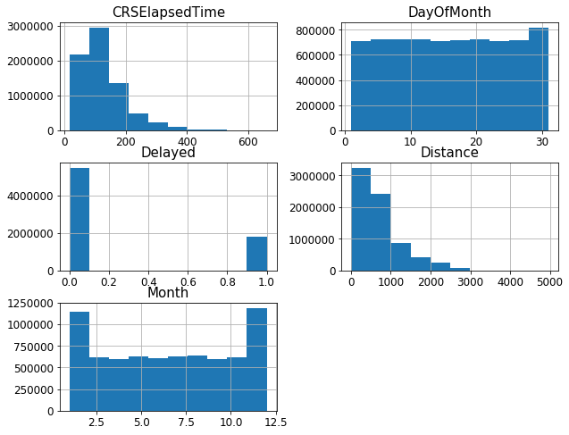

```python
# Let's first quickly review the histogram of all the numerical variables in the dataset
df_clean.hist(figsize=(10,8));
```

```python
# Let's check how many unique values we have per column
df_clean.nunique()
```

```
Month                12
DayOfMonth           31
DayOfWeek             7
UniqueCarrier        20
FlightNum          7593
CRSElapsedTime      546
Origin              304
Dest                304
Distance           1392
CRSArrivalTime       24
Delayed               2
Route              5032
Weekday_Weekend       2
dtype: int64
```

### Univariate Exploration

**#1: What is the distribution of delayed flights in 2007?**

Let's start by looking at the distribution of the main variable of interest: "Delayed".

```python
# Let's define the function for bar chart
def func_bar(X,title,xlabel,ylabel):
    fig, ax = plt.subplots(figsize=(15,6))
    X.plot.bar(color='lightblue')
    plt.title(title, fontweight="bold")
    plt.xlabel(xlabel)
    plt.ylabel(ylabel)
    ax.set_xlabel(xlabel, labelpad=15)
    ax.set_ylabel(ylabel, labelpad=15)
    plt.xticks(rotation=0)
    ax.get_yaxis().set_major_formatter(ticker.FuncFormatter(lambda x, p: format(int(x), ',')))
    return plt.show();
```

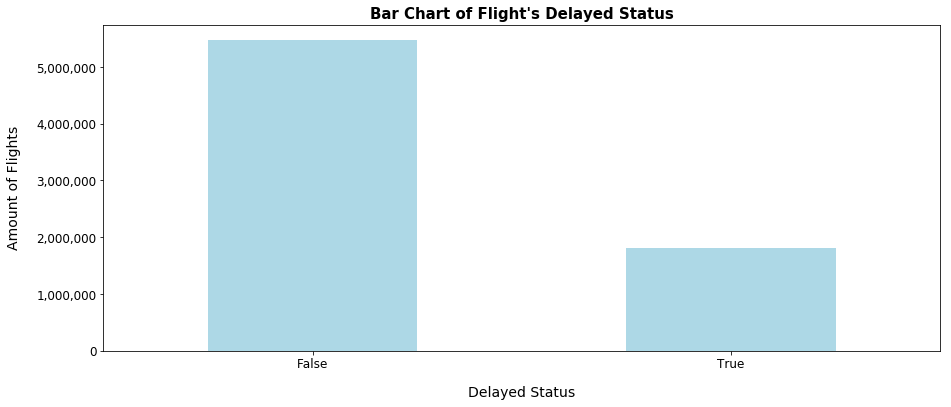

```python
# Let's plot our bar chart for "Delayed"
table = df_clean['Delayed'].value_counts().sort_index()
func_bar(table, "Bar Chart of Flight's Delayed Status", "Delayed Status", "Amount of Flights" )
```

```python
# Let's check the percentage distribution
df_clean['Delayed'].value_counts() / df_clean.shape[0] * 100
```

```
False    75.213075
True     24.786925
Name: Delayed, dtype: float64
```

We can see that, in our clean dataset, 24.8% of flights were delayed.

**#2: What is the distribution of flights per month?**

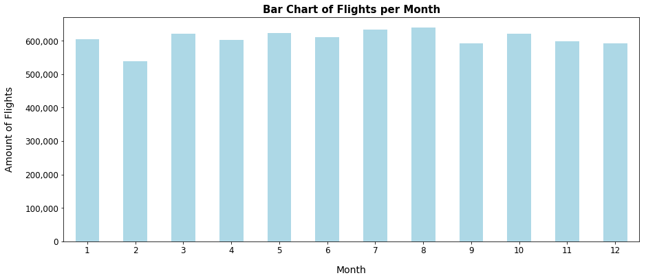

```python
# Let's plot our bar chart for "Month"
table = df_clean['Month'].value_counts().sort_index()
func_bar(table, "Bar Chart of Flights per Month", "Month", "Amount of Flights" )
```

```python
# Let's check the summary statistics of flights per month
table.describe()
```

```
count        12.000000
mean     606271.583333
std       26237.984767
min      538878.000000
25%      596670.250000
50%      607209.000000
75%      622078.750000
max      638880.000000
Name: Month, dtype: float64
```

```python
# Let's define a new function for Bar Chart with mean value displayed and labels in each bar
def func_bar1(X, Y, title, xlabel, ylabel, text_x, text_y, mean, meanlabel,rotation=0):
    fig, ax = plt.subplots(figsize=(15,7))

    plt.bar(np.arange(len(X)),Y,color='lightblue')

    plt.xticks(np.arange(len(X)), X, rotation=rotation)
    plt.title(title, fontweight="bold")
    plt.xlabel(xlabel)
    plt.ylabel(ylabel)
    ax.get_yaxis().set_major_formatter(ticker.FuncFormatter(lambda x, p: format(int(x), ',')))
    ax.set_xlabel(xlabel, labelpad=10)
    ax.set_ylabel(ylabel, labelpad=15)
    for i,v in enumerate(Y):
        if Y.dtypes == "int64":
            ax.text(i - text_x, v + text_y, '{:,.0f}'.format(v), color='blue')
        else:
            ax.text(i - text_x, v + text_y,'{:,.2f}'.format(v), color='blue')
    if mean is not None and meanlabel is not None:
        plt.hlines(mean, xmin=-0.4, xmax=len(X)-0.6, linestyles='dashed', label=meanlabel, color='grey')
        ax.text(len(X) - 0.6 - text_x, mean + text_y*2,'{:,.2f}'.format(mean), color='black')
        plt.legend()
    return plt.show();
```

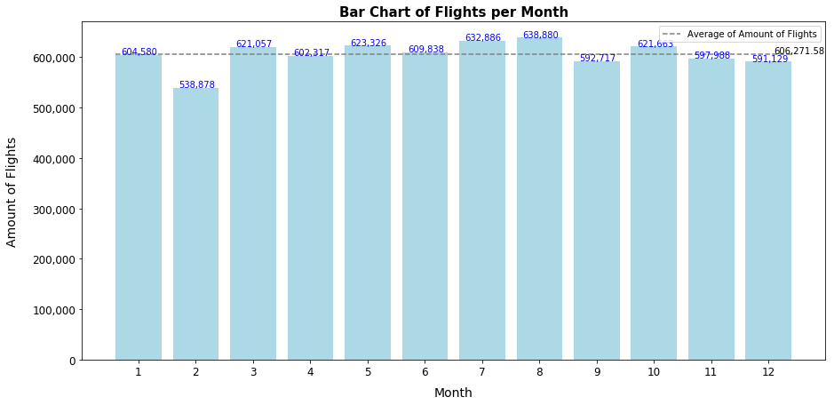

```python
# Let's plot our Bar Chart of flights per month with the labels of each bar displayed
# and with a mean line displayed
x = pd.DataFrame(table.index.values, columns=['x'])
y = pd.DataFrame(table.values, columns=['y'])
title = "Bar Chart of Flights per Month"
func_bar1(x['x'], y['y'], title, "Month", "Amount of Flights" , 0.3, 1000, y.y.mean(), 'Average of Amount of Flights')
```

Overall, we can see that, in our clean dataset, the distribution of flights per month is uniform, with a mean of 606,272 flights per month. However, we can see that February 2007 has way less flights than the rest of the months of 2007. Let's check in a Boxplot if this is an outlier.

```python
# Let's define the function for Boxplot of Quantitative Values

def func_box(X, var_name, xlabel, decimal=0):
    fig, ax = plt.subplots(figsize=(16,6))
    bp = plt.boxplot(X, vert=False, showmeans=True)
    plt.title('Boxplot of {}'.format(var_name), fontweight="bold")
    plt.xlabel(xlabel)
    plt.yticks([1],["Boxplot"], rotation=90, verticalalignment="center")
    ax.grid(b=True, axis='x')
    ax.get_xaxis().set_major_formatter(ticker.FuncFormatter(lambda x, p: format(int(x), ',')))
    # Adding mean label
    if abs(X.mean() - X.median()) < 0.1:
        ax.text(X.mean(), 1.02, '%.2f' %(X.mean()),color='green')
    elif abs(X.mean() - X.median()) < 1:
        ax.text(X.mean(), 1.02, '%.1f' %(X.mean()),color='green')
    else:
        ax.text(X.mean(), 1.02, '%.0f' %(X.mean()),color='green')

    # Adding median label
    x, y = bp['medians'][0].get_xydata()[1]
    if abs(X.mean() - X.median()) < 0.1:
        ax.text(x, y+0.01, '%.2f' % x, horizontalalignment='center')
    elif abs(X.mean() - X.median()) < 1:
        ax.text(x, y+0.01, '%.1f' % x, horizontalalignment='center')
    else:
        ax.text(x, y+0.01, '%.0f' % x, horizontalalignment='center')

    if decimal == 0:
        # Adding quantiles labels
        x, y = bp['boxes'][0].get_xydata()[0]
        ax.text(x,y-0.01, '%.0f' % x, horizontalalignment='center', verticalalignment='top')
        x, y = bp['boxes'][0].get_xydata()[3]
        ax.text(x,y-0.01, '%.0f' % x, horizontalalignment='center', verticalalignment='top')

        # Adding whiskers labels
        x, y = bp['caps'][0].get_xydata()[0]
        ax.text(x,y-0.01, '%.0f' % x, horizontalalignment='center', verticalalignment='top')
        x, y = bp['whiskers'][1].get_xydata()[1]
        ax.text(x,y-0.05, '%.0f' % x, horizontalalignment='center', verticalalignment='top')

    else:
        # Adding quantiles labels
        x, y = bp['boxes'][0].get_xydata()[0]
        ax.text(x,y-0.01, '%.1f' % x, horizontalalignment='center', verticalalignment='top')
        x, y = bp['boxes'][0].get_xydata()[3]
        ax.text(x,y-0.01, '%.1f' % x, horizontalalignment='center', verticalalignment='top')

        # Adding whiskers labels
        x, y = bp['caps'][0].get_xydata()[0]
        ax.text(x,y-0.01, '%.1f' % x, horizontalalignment='center', verticalalignment='top')
        x, y = bp['whiskers'][1].get_xydata()[1]
        ax.text(x,y-0.05, '%.1f' % x, horizontalalignment='center', verticalalignment='top')

    return plt.show();
```

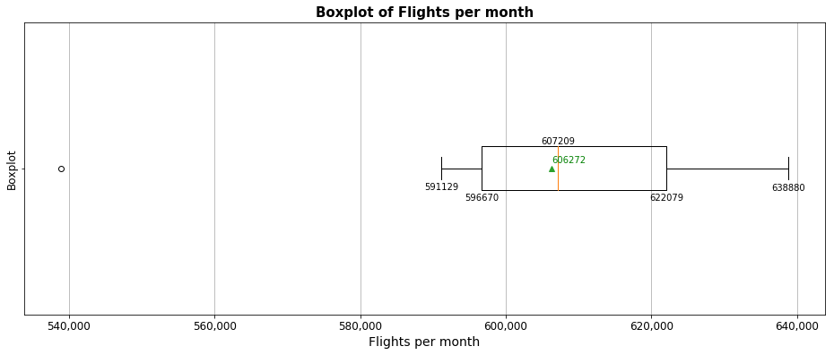

```python
# Let's see the boxplot of flights per month
func_box(table, 'Flights per month', 'Flights per month')
```

We can see that the amount of flights of February 2007 is indeed an outlier.  
Checking the [February 2007 events in USA](https://en.wikipedia.org/wiki/2007_in_the_United_States#February), it seems that the unseasonal tornado in central Florida could have been the reason of the lower flights in that month, considering Orlando is a hot vacation spot in USA and the Tornado was closer to that area. Further investigation of what happened that month in US domestic flights should be performed.

**#3: What is the distribution of flights per day of week?**

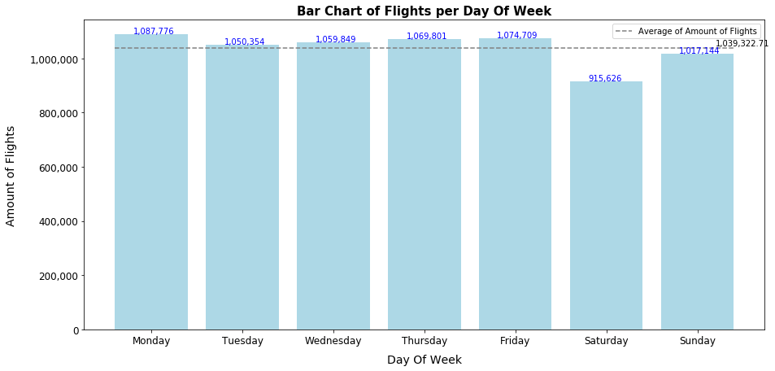

```python
# Let's plot our bar chart for "DayOfWeek"
table = df_clean['DayOfWeek'].value_counts().sort_index()
x = table.index.values
y = pd.DataFrame(table.values, columns=['y'])
title = "Bar Chart of Flights per Day Of Week"
func_bar1(x, y['y'], title, "Day Of Week", "Amount of Flights" , 0.2, 3000, y.y.mean(), 'Average of Amount of Flights')
```

Overall, we can see that, in our clean dataset, the distribution of flights per day of week is somewhat uniform, with a mean of 1,039,323 flights per day of week. However, we can see that Saturday has way less flights than the rest of the days of the week. Let's check in a Boxplot if this is an outlier.

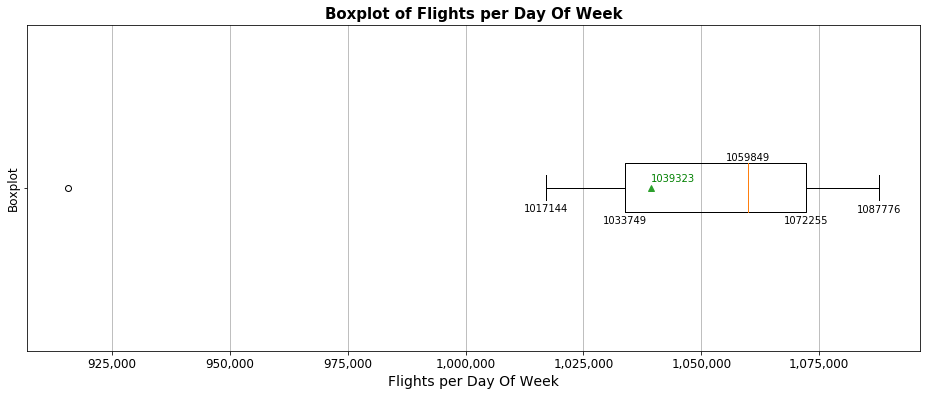

```python
# Let's see the boxplot of flights per "DayOfWeek"
func_box(table, 'Flights per Day Of Week', 'Flights per Day Of Week')
```

We can see that the amount of flights of Saturday is indeed an outlier. Also, it's worth noticing that because of that outlier, the mean of Flights per Day of Week (1,039,323) is less than the median (1,059,849). We should take this into consideration when deciding to use median or mean for our analysis.

**#4: What is the distribution of flights on weekend and weekday? Do people travel more on any of them?**

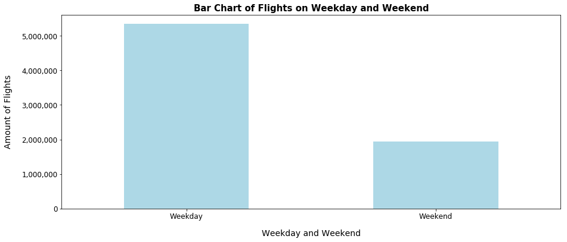

```python
# Let's plot our bar chart for "Weekday_Weekend"
table = df_clean['Weekday_Weekend'].value_counts().sort_index()
func_bar(table, "Bar Chart of Flights on Weekday and Weekend", "Weekday and Weekend", "Amount of Flights" )
```

```python
# Let's check the percentage of flights per "Weekday_Weekend"
df_clean['Weekday_Weekend'].value_counts() / df_clean.shape[0] * 100
```

```
Weekday    73.433661
Weekend    26.566339
Name: Weekday_Weekend, dtype: float64
```

We can see that, in our clean dataset, 73.4% of flights happened during weekdays. This is no surprise since the distribution of flights per day of week was pretty uniform.

**#5: What is the distribution of flights per hour (based on Scheduled Arrival Time)? What are the preferred times for flights to occur?**

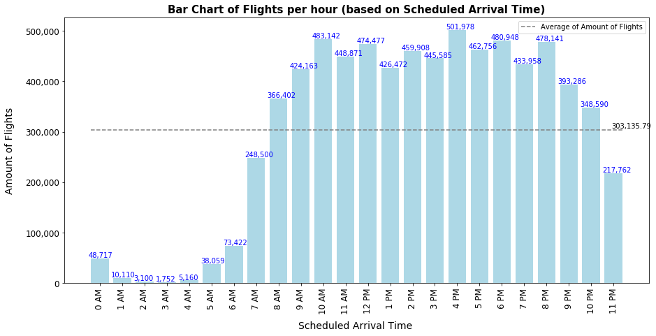

```python
# Let's plot our bar chart of "CRSArrivalTime"
table = df_clean['CRSArrivalTime'].value_counts().sort_index()
x = table.index.values
y = pd.DataFrame(table.values, columns=['y'])
title = "Bar Chart of Flights per hour (based on Scheduled Arrival Time)"
func_bar1(x, y['y'], title, "Scheduled Arrival Time ", "Amount of Flights" , 0.5, 2000, y.y.mean(), 'Average of Amount of Flights',90)
```

In the Bar Chart above we can see that, in our clean dataset, the distribution of Flights per hour (based on Scheduled Arrival Time) is skewed to the left. We can also spot a clear flight reduction between 0 AM and 6 AM (inclusive).  
Let's check if these hour ranges are outliers.

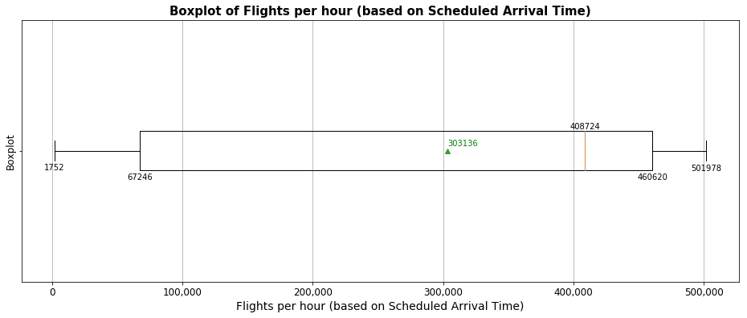

```python
# Let's see the boxplot of flights per hour (based on Scheduled Arrival Time)
func_box(table, 'Flights per hour (based on Scheduled Arrival Time)', 'Flights per hour (based on Scheduled Arrival Time)')
```

According to the IQR criteria, there are no outliers in the distribution of Flights based on Scheduled Arrival Time (per hour). However, it's worth noticing that because of those fewer amounts between 0 AM - 6 AM , the mean of Flights per Hour (303,136) is less than the median (408,724).  
Because of that left skewness, we prefer to use the median for our analysis. Therefore, in our clean dataset, the preferred hours to flight are between 9AM - 8PM (inclusive), because their flight counts are above the median.

**#6: What are the Top 5 Carriers based on their annual number of flights? What is the airline that had the most flights in 2007?**

```python
# Let's get the Top 5 Carriers based on their annual number of flights
table = df_clean['UniqueCarrier'].value_counts().head(5)
table
```

```
WN    1156958
AA     613836
OO     582871
MQ     516205
UA     477090
Name: UniqueCarrier, dtype: int64
```

```python
# Let's get the Average Amount of Flights per Carrier
mean = df_clean['UniqueCarrier'].value_counts().mean()
mean
```

```
363762.95000000001
```

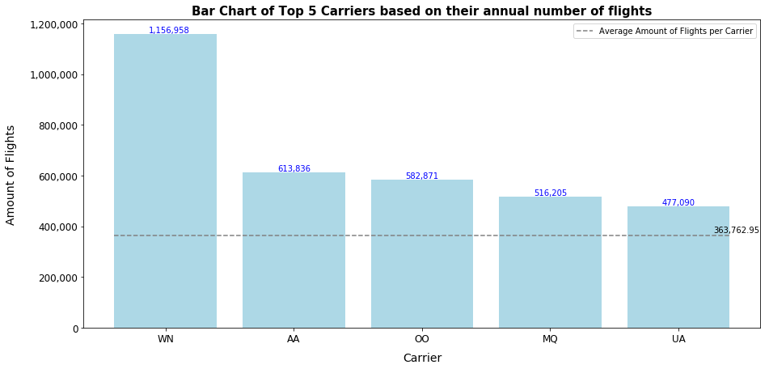

```python
# Let's plot a bar chart
x = table.index.values
y = pd.DataFrame(table.values, columns=['y'])
title = "Bar Chart of Top 5 Carriers based on their annual number of flights"
func_bar1(x, y['y'], title, "Carrier", "Amount of Flights" , 0.13, 6000, mean, 'Average Amount of Flights per Carrier')
```

```python
# Let's get the annual number of flights of "WN"
wn_flights = y.y[0]
print(wn_flights)

# Let's calculate how much higher is its annual count compared to the general mean
(wn_flights - mean) / mean
```

```
1156958
```

```
2.1805273186837746
```

We can see that, in our clean dataset, Southwest Airlines (WN) is the carrier who had the highest annual number of flights (even 2 times higher than the average amount of flights per carrier).

**#7: What are the Top 10 Airports based on their annual amount of flights as origin?**

```python
# Let's get the Top 10 Airports based on their annual amount of flights as origin
table = df_clean['Origin'].value_counts().head(10)
table
```

```
ATL    406136
ORD    358462
DFW    287372
DEN    236650
LAX    233939
PHX    208203
IAH    197869
LAS    181401
DTW    173020
MSP    151965
Name: Origin, dtype: int64
```

```python
# Let's get the Average Amount of Flights per Origin
mean = df_clean['Origin'].value_counts().mean()
mean
```

```
23931.77302631579
```

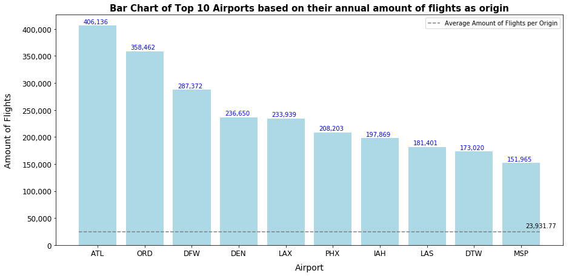

```python
# Let's plot a bar chart
x = table.index.values
y = pd.DataFrame(table.values, columns=['y'])
title = "Bar Chart of Top 10 Airports based on their annual amount of flights as origin"
func_bar1(x, y['y'], title, "Airport", "Amount of Flights" , 0.3, 4000, mean, 'Average Amount of Flights per Origin')
```

```python
# Let's get the annual number of flights with "ATL" as origin
atl_flights = y.y[0]
print(atl_flights)

# Let's calculate how much higher is its annual count compared to the general mean
(atl_flights - mean) / mean
```

```
406136
```

```
15.970577129968843
```

We can see that, in our clean dataset, Atlanta's Hartsfield-Jackson (ATL) is the airport who had the highest annual number of flights as origin (even 15 times higher than the average amount of flights per origin).

**#8: What are the Top 10 Airports based on their annual amount of flights as destination?**

```python
# Let's get the Top 10 Airports based on their annual amount of flights as destination
table = df_clean['Dest'].value_counts().head(10)
table
```

```
ATL    404970
ORD    357261
DFW    285765
DEN    236330
LAX    234050
PHX    207723
IAH    197088
LAS    181832
DTW    172679
MSP    151573
Name: Dest, dtype: int64
```

```python
# Let's get the Average Amount of Flights per Destination
mean = df_clean['Dest'].value_counts().mean()
mean
```

```
23931.77302631579
```

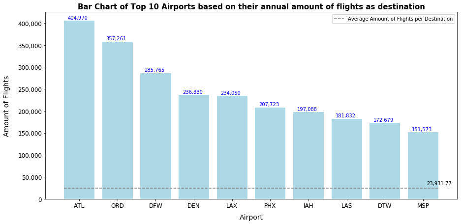

```python
# Let's plot a bar chart
x = table.index.values
y = pd.DataFrame(table.values, columns=['y'])
title = "Bar Chart of Top 10 Airports based on their annual amount of flights as destination"
func_bar1(x, y['y'], title, "Airport", "Amount of Flights" , 0.3, 4000, mean, 'Average Amount of Flights per Destination')
```

```python
# Let's get the annual number of flights with "ATL" as destination
atl_flights = y.y[0]
print(atl_flights)

# Let's calculate how much higher is its annual count compared to the general mean
(atl_flights - mean) / mean
```

```
404970
```

```
15.921855290650134
```

We can see that, in our clean dataset, Atlanta's Hartsfield-Jackson (ATL) is also the airport who had the highest annual number of flights as destination (even 15 times higher than the average amount of flights per destination).

**#9: What are the Top 5 Flight Numbers based on their annual number of operations? What are the Routes associated?**

```python
# Let's get the Top 5 Flight Numbers based on their annual number of flights
table = df_clean['FlightNum'].value_counts().head(5)
table
```

```
16     5317
1      5198
67     4946
529    4916
500    4879
Name: FlightNum, dtype: int64
```

```python
# Let's get the Average Amount of Flights per Flight Number
mean = df_clean['FlightNum'].value_counts().mean()
mean
```

```
958.15343079151853
```

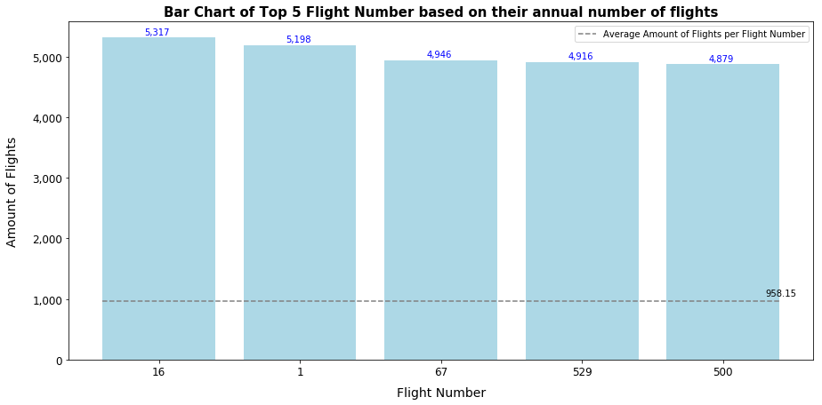

```python
# Let's plot a bar chart
x = table.index.values
y = pd.DataFrame(table.values, columns=['y'])
title = "Bar Chart of Top 5 Flight Number based on their annual number of flights"
func_bar1(x, y['y'], title, "Flight Number", "Amount of Flights" , 0.1, 50, mean, 'Average Amount of Flights per Flight Number')
```

```python
# Let's get the annual number of flights of "16"
flights = y.y[0]
print(flights)

# Let's calculate how much higher is its annual count compared to the general mean
(flights - mean) / mean
```

```
5317
```

```
4.5492156361718523
```

```python
# Let's check the unique values of every column of flights with "16" as Flight Number
df_clean[df_clean['FlightNum'] == "16"].nunique()
```

```
Month              12
DayOfMonth         31
DayOfWeek           7
UniqueCarrier      11
FlightNum           1
CRSElapsedTime     69
Origin             19
Dest               16
Distance           27
CRSArrivalTime     18
Delayed             2
Route              27
Weekday_Weekend     2
dtype: int64
```

We can see that, in our clean dataset, "16" is the Flight Number who had the highest annual number of fligths (even 4 times higher than the average amount of flights per flight number). However, we see that there is not a single origin, destination or route associated with it, but several.

**#10: What are the Top 10 Routes (origin - destination) based on their annual number of operations?**

```python
# Let's get the Top 10 Routes (origin - destination) based on their annual number of operations
table = df_clean['Route'].value_counts().head(10)
table
```

```
OGG - HNL    15922
HNL - OGG    15713
LAX - LAS    14133
LAS - LAX    13583
HNL - LIH    13093
LIH - HNL    12959
LAX - SAN    12604
SAN - LAX    12585
LAS - PHX    11922
PHX - LAX    11616
Name: Route, dtype: int64
```

```python
# Let's get the Average Amount of Flights per Route
mean = df_clean['Route'].value_counts().mean()
mean
```

```
1445.7986883942767
```

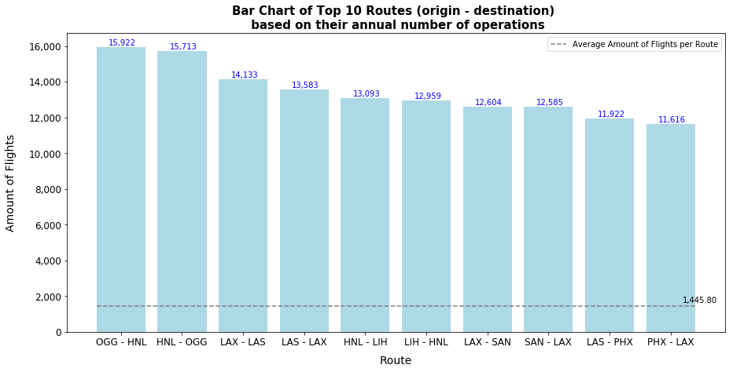

```python
# Let's plot a bar chart
x = table.index.values
y = pd.DataFrame(table.values, columns=['y'])
title = "Bar Chart of Top 10 Routes (origin - destination) \n based on their annual number of operations"
func_bar1(x, y['y'], title, "Route", "Amount of Flights" , 0.2, 100, mean, 'Average Amount of Flights per Route')
```

```python
# Let's get the annual number of flights with "OGG-HNL" as route
flights = y.y[0]
print(flights)

# Let's calculate how much higher is its annual count compared to the general mean
(flights - mean) / mean
```

```
15922
```

```
10.012598176917137
```

We also noticed that Atlanta's Hartsfield-Jackson airport (ATL) does not appear in the Top 10 Route (based on their annual number of operations) despite being the Top Airport (based on their annual number of operations) as origin and destination.

**#11: What is the distribution of Distance between airports?**

```python
# Let's define the function for Histograms of Quantitative Continuous Values

def func_hist(x,var_name, xlabel,ylabel):
    fig,ax = plt.subplots(figsize=(15,8))
    plt.hist(x, bins='auto')
    plt.title('Histogram of {}'.format(var_name), fontweight="bold")
    plt.xlabel(xlabel)
    plt.ylabel(ylabel)
    ax.set_xlim(0,)
    ax.set_ylim(0,)
    ax.get_yaxis().set_major_formatter(ticker.FuncFormatter(lambda x, p: format(int(x), ',')))
    return plt.show();
```

It's importat to notice that we chose the "auto" method to select the number of bins of histograms. These auto method chooses the maximum number of bins between the "Sturges" and "Freedman Diaconis" estimators.

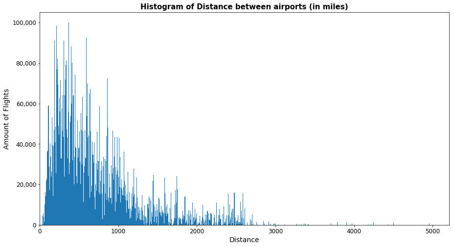

```python
# Let's see the histogram in detail for "distance" column
func_hist(df_clean['Distance'], 'Distance between airports (in miles)', 'Distance', 'Amount of Flights')
```

In the histogram above we see that, in our clean dataset, the distribution of Distance between airports is skewed to the right. This shows that most of the flights in our clean dataset had a distance between airports lower than 2,000 miles compared to the minimum amount of Flights who had a distance over 2,000. This higher-distance flights can even be up to 5,000 miles.

```python
# Let's see the summary statistics of "Distance" column
df_clean['Distance'].describe().astype(int)
```

```
count    7275259
mean         722
std          563
min           11
25%          320
50%          570
75%          948
max         4962
Name: Distance, dtype: int64
```

From the summary statistics, we see that the majority of Flights in our clean dataset (between 25% and 75% percentile) had a Distance between airports between 320 and 948 miles.

```python
# Let's define the function for Histograms with Log Transformation on the x axis

def func_hist_log(x,var_name, xlabel,ylabel, bins='auto'):
    fig,ax = plt.subplots(figsize=(15,8))
    plt.hist(x, bins=bins)
    plt.title('Histogram of {}'.format(var_name), fontweight="bold")
    plt.xlabel(xlabel)
    plt.ylabel(ylabel)
    plt.xscale('log')
    ax.get_yaxis().set_major_formatter(ticker.FuncFormatter(lambda x, p: format(int(x), ',')))
    return plt.show();
```

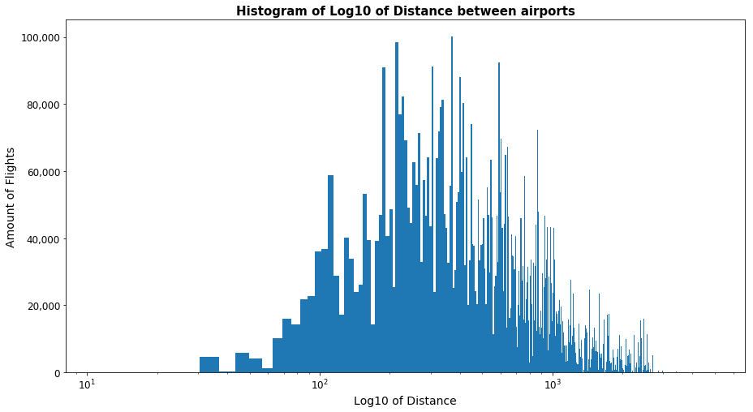

```python
# Let's see the histogram of "distance" column after a log transformation on x axis
func_hist_log(df_clean['Distance'], 'Log10 of Distance between airports', 'Log10 of Distance', 'Amount of Flights')
```

```python
# Let's define the density function with log transformation on x axis
def func_density_log(x, var_name, xlabel):
    fig, ax = plt.subplots(figsize=(15,5))
    sns.kdeplot(x, shade=True)
    plt.title('Density Plot of {}'.format(var_name))
    plt.xlabel(xlabel)
    plt.ylabel('Density')
    plt.xscale('log')
    return plt.show();
```

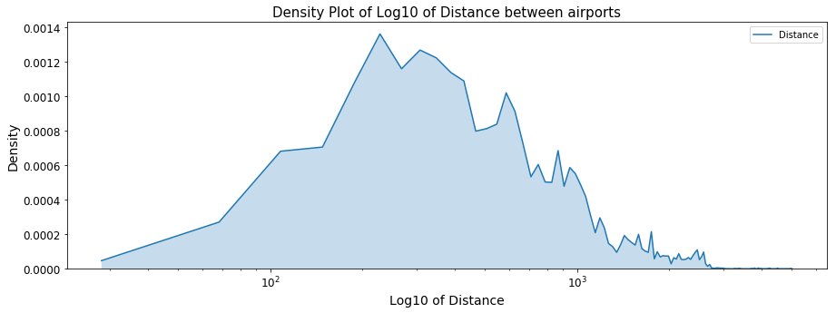

```python
# Let's plot the density function of "distance" column after a log transformation on x axis
func_density_log(df_clean['Distance'], 'Log10 of Distance between airports', 'Log10 of Distance')
```

When plotted on a log-scale, the distribution of Distance between airports looks roughly normal with a light right skew. We can see there's a steep reduction in the right tail, rather than a smooth ramp down.

```python
# Let's define the function for Boxplot with Log Scale in the X axis

def func_box_log(X, var_name, xlabel, decimal=0):
    fig, ax = plt.subplots(figsize=(16.5,6))
    bp = plt.boxplot(X, vert=False, showmeans=True)
    plt.title('Boxplot of {}'.format(var_name), fontweight="bold")
    plt.xlabel(xlabel)
    plt.yticks([1],["Boxplot"], rotation=90, verticalalignment="center")
    ax.grid(b=True, axis='x')
    plt.xscale('log')
    # Adding mean label
    if abs(X.mean() - X.median()) < 0.1:
        ax.text(X.mean(), 1.02, '%.2f' %(X.mean()),color='green')
    elif abs(X.mean() - X.median()) < 1:
        ax.text(X.mean(), 1.02, '%.1f' %(X.mean()),color='green')
    else:
        ax.text(X.mean(), 1.02, '%.0f' %(X.mean()),color='green')

    # Adding median label
    x, y = bp['medians'][0].get_xydata()[1]
    if abs(X.mean() - X.median()) < 0.1:
        ax.text(x, y+0.01, '%.2f' % x, horizontalalignment='center')
    elif abs(X.mean() - X.median()) < 1:
        ax.text(x, y+0.01, '%.1f' % x, horizontalalignment='center')
    else:
        ax.text(x, y+0.01, '%.0f' % x, horizontalalignment='center')

    if decimal == 0:
        # Adding quantiles labels
        x, y = bp['boxes'][0].get_xydata()[0]
        ax.text(x,y-0.01, '%.0f' % x, horizontalalignment='center', verticalalignment='top')
        x, y = bp['boxes'][0].get_xydata()[3]
        ax.text(x,y-0.01, '%.0f' % x, horizontalalignment='center', verticalalignment='top')

        # Adding whiskers labels
        x, y = bp['caps'][0].get_xydata()[0]
        ax.text(x,y-0.01, '%.0f' % x, horizontalalignment='center', verticalalignment='top')
        x, y = bp['whiskers'][1].get_xydata()[1]
        ax.text(x,y-0.05, '%.0f' % x, horizontalalignment='center', verticalalignment='top')

    else:
        # Adding quantiles labels
        x, y = bp['boxes'][0].get_xydata()[0]
        ax.text(x,y-0.01, '%.1f' % x, horizontalalignment='center', verticalalignment='top')
        x, y = bp['boxes'][0].get_xydata()[3]
        ax.text(x,y-0.01, '%.1f' % x, horizontalalignment='center', verticalalignment='top')

        # Adding whiskers labels
        x, y = bp['caps'][0].get_xydata()[0]
        ax.text(x,y-0.01, '%.1f' % x, horizontalalignment='center', verticalalignment='top')
        x, y = bp['whiskers'][1].get_xydata()[1]
        ax.text(x,y-0.05, '%.1f' % x, horizontalalignment='center', verticalalignment='top')

    return plt.show();
```

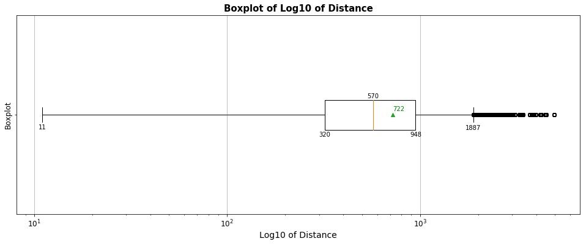

```python
# Let's see the boxplot of Distance with a Log-scale
func_box_log(df_clean['Distance'], 'Log10 of Distance', 'Log10 of Distance')
```

Since we have a great amount of outliers with high values, the mean (722) is much greater than the median (570) in the Distribution of Log10 of Distance.

**#12: What is the distribution of Scheduled Elapsed Time?**

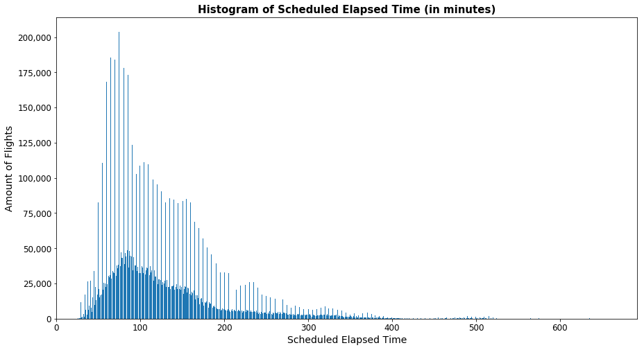

```python
# Let's see the histogram in detail for "CRSElapsedTime" column
func_hist(df_clean['CRSElapsedTime'], 'Scheduled Elapsed Time (in minutes)', 'Scheduled Elapsed Time', 'Amount of Flights')
```

In the histogram above we see that, in our clean dataset, the distribution of Scheduled Elapsed Time is skewed to the right. This shows that most of the flights in our clean dataset had a Scheduled Elapsed Time lower than 400 minutes compared to the minimum amount of Flights who had a time over 400. This higher Scheduled Elapsed Time flights can even be over 600 minutes.

```python
# Let's see the summary statistics of "CRSElapsedTime" column
df_clean['CRSElapsedTime'].describe().astype(int)
```

```
count    7275259
mean         127
std           70
min           18
25%           78
50%          110
75%          157
max          660
Name: CRSElapsedTime, dtype: int64
```

From the summary statistics, we see that the majority of Flights in our clean dataset (between 25% and 75% percentile) had a Scheduled Elapsed Time between 78 and 157 minutes.

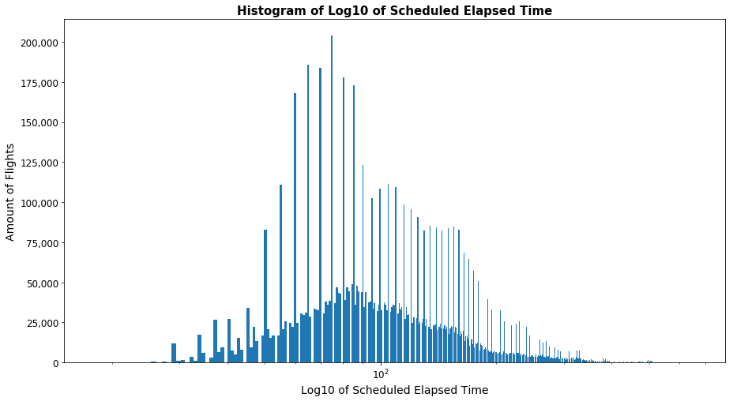

```python
# Let's see the histogram of "CRSElapsedTime" column after a log transformation on x axis
func_hist_log(df_clean['CRSElapsedTime'], 'Log10 of Scheduled Elapsed Time', 'Log10 of Scheduled Elapsed Time', 'Amount of Flights')
```

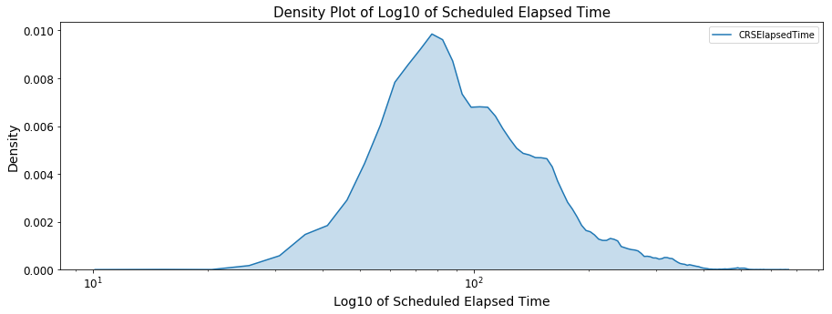

```python
# Let's plot the density function of "CRSElapsedTime" column after a log transformation on x axis
func_density_log(df_clean['CRSElapsedTime'], 'Log10 of Scheduled Elapsed Time', 'Log10 of Scheduled Elapsed Time')
```

When plotted on a log-scale, the Scheduled Elapsed Time looks roughly normal with a light right skew. We can see that there's a steep reduction in the right tail, rather than a smooth ramp down.

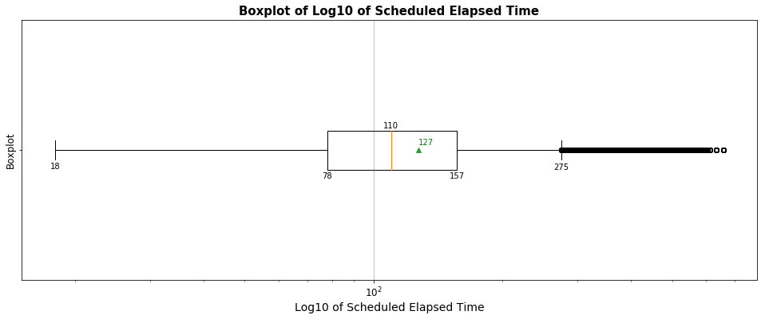

```python
# Let's see the boxplot of Scheduled Elapsed Time with a Log-scale
func_box_log(df_clean['CRSElapsedTime'], 'Log10 of Scheduled Elapsed Time', 'Log10 of Scheduled Elapsed Time')
```

Since we have a great amount of outliers with high values, the mean (127) is much greater than the median (110) in the Distribution of Log10 of Scheduled Elapsed Time.

### Let's discuss the distribution of the variable of interest.

The "delayed" variable is a Boolean, with an unbalance towards the negative (not delayed). This was not a surprise because most airlines report time-related KPIs to the aviation authorities and airports in order to keep their operations.

### Of the features investigated, were there any unusual distributions? Were there any operations needed to be performed on the data to tidy, adjust, or change its form?

All the above is something to keep an eye out for the rest of the analysis.

### Bivariate Exploration

**#1: What is the percentage of flight operations that arrived late each month?**

```python
# Let's define a function for stacked bar chart, with absolute counts

def func_stack_bar_abs(df, cat1_order, cat2_order, cat_var1, cat_var2, ylabel):
    baselines = np.zeros(len(cat1_order))
    fig, ax = plt.subplots(figsize=(12, 5))
    plt.xlabel(cat_var1)
    plt.ylabel(ylabel)
    plt.title('Stacked bar chart, with absolute counts')
    # for each second-variable category:
    for i in range(len(cat2_order)):
        # isolate the counts of the first category,
        cat2 = cat2_order[i]
        inner_counts = df[df[cat_var2] == cat2][cat_var1].value_counts()
        # then plot those counts on top of the accumulated baseline
        plt.bar(x = np.arange(len(cat1_order)), height = inner_counts[cat1_order],bottom = baselines)
        baselines += inner_counts[cat1_order]
    ax.get_yaxis().set_major_formatter(ticker.FuncFormatter(lambda x, p: format(int(x), ',')))
    plt.xticks(np.arange(len(cat1_order)), cat1_order)
    plt.legend(cat2_order, title = cat_var2);
```

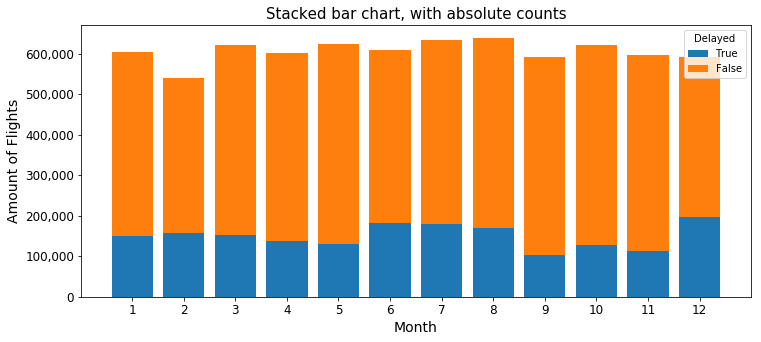

```python
# Let's plot a stacked bar chart, with absolute counts, for "Delayed" and "Month"
cat1_order = list(range(1,13,1))
cat2_order = [True, False]
cat_var1 = 'Month'
cat_var2 = 'Delayed'
func_stack_bar_abs(df_clean, cat1_order, cat2_order, cat_var1, cat_var2, 'Amount of Flights')
```

In the stacked bar chart above we can see that, in our clean dataset, the amount of delayed flights is always lower than the amount of not delayed flights throughout the months. This means that most of the flights were on time each month.  
However, let's see this more clearly with a stacked bar chart with relative frequency.

```python
# Let's define a function for stacked bar chart, with relative frequency

def func_stack_bar_per(df, cat1_order, cat2_order, cat_var1, cat_var2, ylabel, rotation=0):
    fig, ax = plt.subplots(figsize=(15, 5))
    plt.xlabel(cat_var1)
    ax.set_xlabel(cat_var1, labelpad=10)
    plt.ylabel(ylabel)
    plt.title('Stacked bar chart, with relative frequency')
    artists = [] # for storing references to plot elements
    baselines = np.zeros(len(cat1_order))
    cat1_counts = df[cat_var1].value_counts()

    # for each second-variable category:
    for i in range(len(cat2_order)):
        # isolate the counts of the first category,
        cat2 = cat2_order[i]
        inner_counts = df[df[cat_var2] == cat2][cat_var1].value_counts()
        inner_props = inner_counts / cat1_counts
        # then plot those counts on top of the accumulated baseline
        bars = plt.bar(x = np.arange(len(cat1_order)),
                       height = inner_props[cat1_order],
                       bottom = baselines)
        artists.append(bars)
        baselines += inner_props[cat1_order]

        for r in bars:
            h = r.get_height()
            plt.text(r.get_x() + r.get_width()/2., h/1.5, '{:,.2f}'.format(h), ha="center", color="white")


    plt.xticks(np.arange(len(cat1_order)), cat1_order, rotation=rotation)
    plt.legend(reversed(artists), reversed(cat2_order), framealpha = 1,
               bbox_to_anchor = (1, 0.5), loc = 6, title = cat_var2);
```

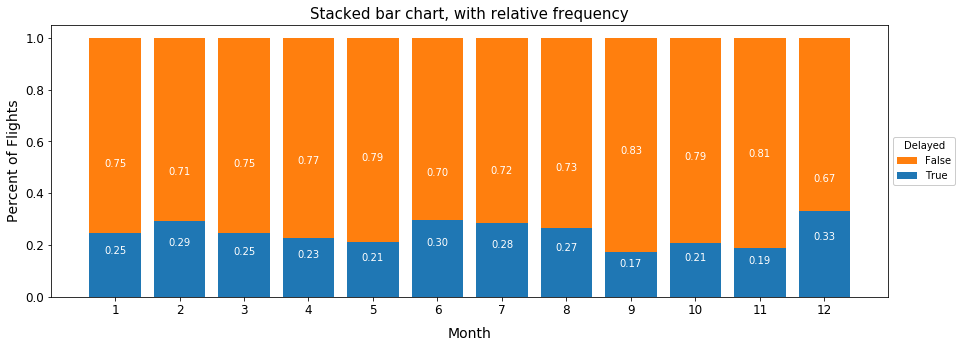

```python
# Let's plot a stacked bar chart, with relative frequency, for "Delayed" and "Month"
cat1_order = list(range(1,13,1))
cat2_order = [True, False]
cat_var1 = 'Month'
cat_var2 = 'Delayed'
func_stack_bar_per(df_clean, cat1_order, cat2_order, cat_var1, cat_var2, 'Percent of Flights')
```

```python
# Let's check the average delay per month
mean = df_clean.groupby('Month')['Delayed'].mean().mean()
mean
```

```
0.24818361855561713
```

```python
# Let's get the maximum delay per month
maximum = df_clean.groupby('Month')['Delayed'].mean().max()
maximum
```

```
0.33165518863056964
```

```python
# Let's check how more the maximum value is above the mean
(maximum - mean)/mean * 100
```

```
33.632989381306331
```

```python
# Let's get the minimum delay per month
minimum = df_clean.groupby('Month')['Delayed'].mean().min()
minimum
```

```
0.17273504893566408
```

```python
# Let's check how less the minimum value is below the mean
(minimum - mean)/mean * 100
```

```
-30.400302025995835
```

In the stacked bar chart above we can see that, in our clean dataset, most of the flights (70% or more) were on time each month. Even though the percentage of delays per month follows a somewhat uniform distribution, there was a notable increment in the percentage of delayed flights during December 2007: 33% of flights were delayed that month, which is 34% higher than the average delay per month.

Also, September 2007 has the lowest percent of delayed flights: only 17% of flights were delayed that month, which is 30% lower than the average delay per month.

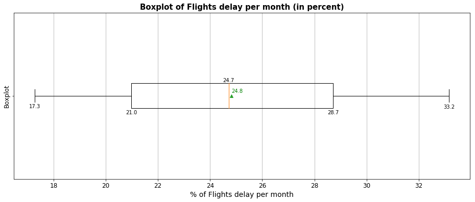

```python
# Let's see the boxplot of Percentage of flights' delay per month
table = df_clean.groupby('Month')['Delayed'].mean()*100
func_box(table, 'Flights delay per month (in percent)', '% of Flights delay per month', 2)
```

In the boxplot above we see that, in our clean dataset, the majority of months (between 25% and 75% percentile) had a Percentage of Flight Delay between 21 and 28.7%.

**#2: What is the percentage of flight operations that arrived late each day of week?**

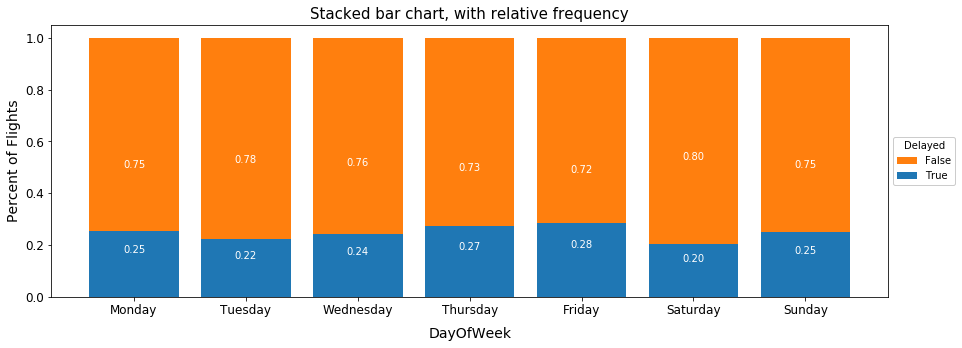

```python
# Let's plot a stacked bar chart, with relative frequency, for "Delayed" and "DayOfWeek"
cat1_order = df_clean.DayOfWeek.unique()
cat2_order = [True, False]
cat_var1 = 'DayOfWeek'
cat_var2 = 'Delayed'
func_stack_bar_per(df_clean, cat1_order, cat2_order, cat_var1, cat_var2, 'Percent of Flights')
```

```python
# Let's check the average delay per Day Of Week
mean = df_clean.groupby('DayOfWeek')['Delayed'].mean().mean()
mean
```

```
0.24687216965800027
```

```python
# Let's get the maximum delay per Day Of Week
maximum = df_clean.groupby('DayOfWeek')['Delayed'].mean().max()
maximum
```

```
0.28364980659880956
```

```python
# Let's check how more the maximum value is above the mean
(maximum - mean)/mean * 100
```

```
14.897441453914592
```

In the stacked bar chart above we can see that, in our clean dataset, most of the flights (70% or more) were on time each day of the week. Even though the percentage of delays per day of week follows a somewhat uniform distribution, Friday had the highest percent of the week: 28% of flights were delayed that day, which is 15% higher than the average delay per day of week.

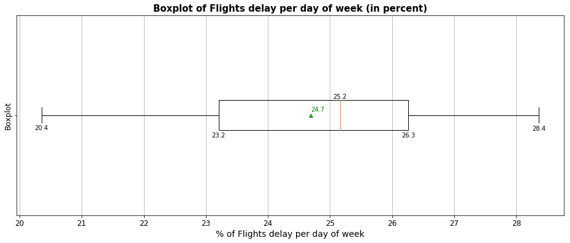

```python
# Let's see the boxplot of Percentage of flights' delay per day of week
table = df_clean.groupby('DayOfWeek')['Delayed'].mean()*100
func_box(table, 'Flights delay per day of week (in percent)', '% of Flights delay per day of week', 2)
```

In the boxplot above we see that, in our clean dataset, the majority of days of the week (between 25% and 75% percentile) had a Percentage of Flight Delay between 23.2 and 26.3%.

**#3: What is the percentage of flight operations that arrived late per hour (Schedule Arrival Time)?**

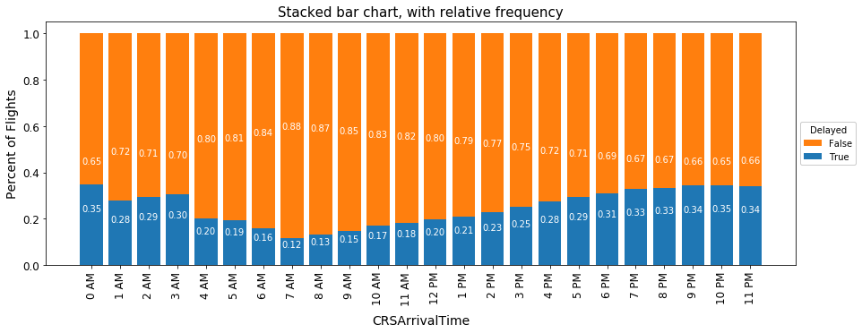

```python
# Let's plot a stacked bar chart, with relative frequency, for "Delayed" and "CRSArrivalTime"
cat1_order = df_clean.CRSArrivalTime.cat.categories
cat2_order = [True, False]
cat_var1 = 'CRSArrivalTime'
cat_var2 = 'Delayed'
func_stack_bar_per(df_clean, cat1_order, cat2_order, cat_var1, cat_var2, 'Percent of Flights', 90)
```

```python
# Let's check the average delay per "CRSArrivalTime"
mean = df_clean.groupby('CRSArrivalTime')['Delayed'].mean().mean()
mean
```

```
0.24974743177705414
```

```python
# Let's get the maximum delay per "CRSArrivalTime"
maximum = df_clean.groupby('CRSArrivalTime')['Delayed'].mean().max()
maximum
```

```
0.34725044645606257
```

```python
# Let's check how more the maximum value is above the mean
(maximum - mean)/mean * 100
```

```
39.040647579530649
```

```python
# Let's get the minimum delay per "CRSArrivalTime"
minimum = df_clean.groupby('CRSArrivalTime')['Delayed'].mean().min()
minimum
```

```
0.11762575452716298
```

```python
# Let's check how more the minimum value is above the mean
(minimum - mean)/mean * 100
```

```
-52.902116474148265
```

In the stacked bar chart above we can see that, in our clean dataset, most of the flights (65% or more) were on time each hour (Schedule Arrival Time). We also noticed a spike in the percent of delays per hour between 9 PM and 0 AM (inclusive), and a notable reduction in the percent of delays at 7 AM. The highest value (at 10 PM and 0 AM) was 39% above the mean and the lowest value (7 AM) was 53% below the mean.

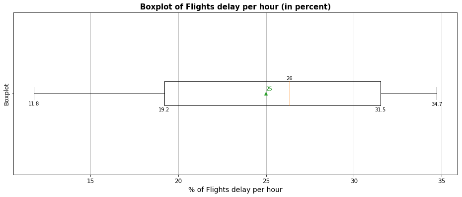

```python
# Let's see the boxplot of Percentage of flights' delay per "CRSArrivalTime"
table = df_clean.groupby('CRSArrivalTime')['Delayed'].mean()*100
func_box(table, 'Flights delay per hour (in percent)', '% of Flights delay per hour', 2)
```

In the boxplot above we see that, in our clean dataset, the majority of Schedule Arrival hours (between 25% and 75% percentile) had a Percentage of Flight Delay between 19.2% and 31.5%.